# Contributions from iNaturalist national sites

Data analyses

Author

Florencia Grattarola

Published

August 7, 2026

The aim of this report is to give an account of the importance of the iNaturalist network members by analysing the number of records for each country.

```r
library(lme4)
library(lmerTest)
library(performance)
library(sjPlot)
library(ggeffects)
library(knitr)
library(rgbif)
library(ggrepel)
library(extrafont)
library(patchwork)
library(sf)
sf_use_s2(FALSE)
library(tidymodels)
library(tidyverse)

options(knitr.kable.NA = '')
options(scipen=999)
```

## iNaturalist National Sites

```r
inat_network <- read_csv('data/inat_nodes.csv', na='')

inat_network %>%
  mutate('#'= row_number()) %>% relocate('#') %>%
  rename(`Country` = node_country,
         `Node name` = node_name,
         `ID`= node_id,
         `Type`=node_type,
         `Year established` = node_year) %>%
  kableExtra::kbl(digits=1) %>%
  kableExtra::kable_material('striped') %>%
  kableExtra::row_spec(row = c(1,4,7,8,10,11,12,17,21), bold = T, color = "white", background = "#228A22")
```

Members of the iNaturalist Network. Shown in green are the sites from Latin America

| # | Country | Node name | ID | Type | Year established |
| --- | --- | --- | --- | --- | --- |
| 1 | Mexico | iNaturalistMX | 2 | NGO | 2013 |
| 2 | New Zealand | iNaturalistNZ | 3 | NGO | 2014 |
| 3 | Canada | iNaturalist.ca | 5 | governmental organisation | 2015 |
| 4 | Colombia | NaturalistaCO | 6 | governmental organisation | 2015 |
| 5 | Portugal | BioDiversity4All | 8 | NGO | 2017 |
| 6 | Australia | iNaturalistAU | 9 | governmental organisation | 2017 |
| 7 | Panama | iNaturalistPa | 13 | governmental organisation | 2019 |
| 8 | Ecuador | iNaturalistEc | 14 | governmental organisation | 2019 |
| 9 | Israel | iNaturalistil | 15 | university | 2019 |
| 10 | Argentina | ArgentiNat | 16 | NGO | 2019 |
| 11 | Costa Rica | NaturalistaCR | 17 | governmental organisation | 2019 |
| 12 | Chile | iNaturalistCL | 18 | governmental organisation | 2019 |
| 13 | Finland | iNaturalistFi | 20 | university | 2020 |
| 14 | Sweden | iNaturalist.Se | 21 | university | 2020 |
| 15 | Spain | Natusfera | 22 | governmental organisation | 2020 |
| 16 | Greece | iNaturalistGR | 23 | NGO | 2020 |
| 17 | Guatemala | iNaturalistGT | 24 | governmental organisation | 2020 |
| 18 | United Kingdom | iNaturalistUK | 25 | governmental organisation | 2021 |
| 19 | Luxembourg | iNaturalist.LU | 26 | museum | 2021 |
| 20 | Taiwan | iNaturalistTW | 27 | university | 2022 |
| 21 | Uruguay | NaturalistaUY | 28 | NGO | 2021 |

[figure not shown]

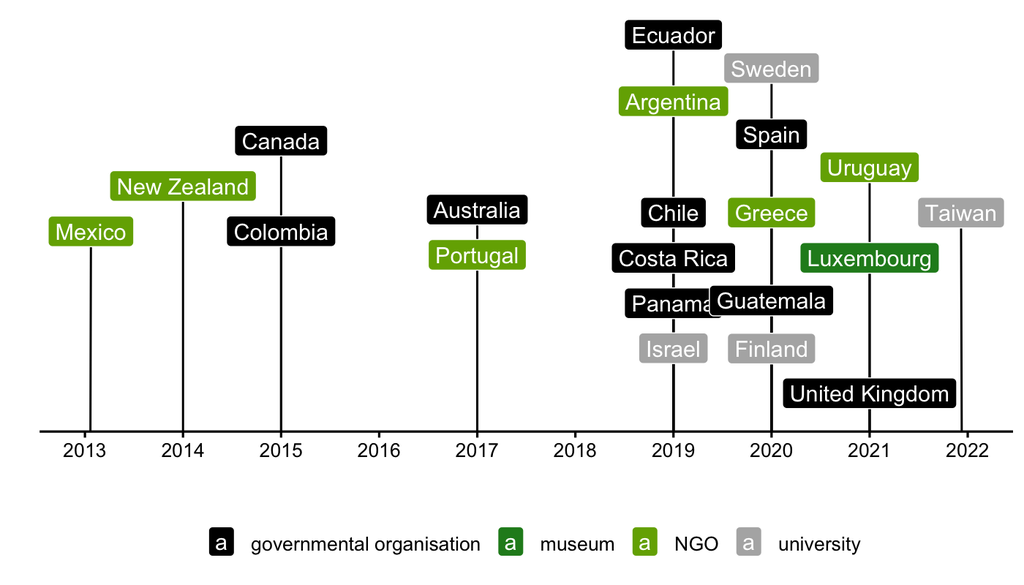

```r
ggplot(inat_network, aes(x = node_year,
                         y = 0,
                         label = node_country)) +
  # geom_point(aes(col = node_type), shape=6, size = 2, show.legend=F) +
  # scale_colour_manual(values = c('black', '#228a22', '#74AC00', '#b2b2b2ff')) +
  scale_x_continuous(breaks = seq(2013, 2022, 1)) +
  geom_label_repel(
    aes(fill = node_type),
    colour = 'white',
    segment.colour = 'black',
    segment.size = 0.5,
    min.segment.length = 0.1,
    # show.legend = FALSE,
    max.overlaps = Inf,
    direction = "y",
    nudge_y = 0.5
  ) +
  scale_fill_manual(values = c('black', '#228a22', '#74AC00', '#b2b2b2ff')) +
  labs(x = '', y = '', fill = '') +
  ggpubr::theme_classic2() +
  theme(
    legend.position = 'bottom',
    axis.text.y = element_blank(),
    axis.ticks.y = element_blank(),
    axis.line.y = element_blank()
  )
```

```r
# plot_zoom_png?width=952&height=374
```

## Methods

We tested different explanatory variables and saw which is the model that best explains the values a country has for iNaturalist. Indicators per country were extracted using the WDI: World Development Indicators (World Bank) on the **20th of March, 2026**.

**Response variables** (per country):

- `n_records`: total number of records on iNaturalist.
- `n_users`: number of users recording (this is not exactly the users *from* the country, but users that have generated records in the country).
- `n_species`: number of species recorded (this is not necessarily at the species level).
- `n_projects`: number of projects created.
- `p_research_grade`: proportion of records from iNaturalist that are “Research Grade” (proxy for quality).
- `n_literature`: number of peer-reviewed publications in GBIF using iNat data.

**Explanatory variables**:

- `population`: population of the country (*SP.POP.TOTL*).
- `area`: area of the country in km<sup>2</sup> (*AG.SRF.TOTL.K2*).
- `gdp_per_capita`: GDP per capita in US dollars (*NY.GDP.PCAP.CD*).
- `gdp_in_research`: % of the GDP of the country dedicated to research *GB.XPD.RSDV.GD.ZS*).
- `latitude`: country’s centroid latitude (as a proxy of expected biodiversity) (using `rnaturalearth` country polygons).
- `iucn_species`: number of species reported for the country on IUCN (using `rnaturalearth` country polygons).
- `has_node`: whether a country has a node on the iNaturalist network.
- `neighbour_has_node`: whether a country has a neighbouring country that has a node on the iNaturalist network (using `rnaturalearth` country polygons).

### Data

```r
data_variables <- read_csv('data/data_global_variables.csv', na = '')
```

## Summary of the data

| Network | Observations | (%) | Users | (%) | Species | (%) | Projects | (%) | Publications | (%) | Proportion of RG | sd |
| --- | --- | --- | --- | --- | --- | --- | --- | --- | --- | --- | --- | --- |
| Network | 94,618,527 | 28.9 | 1,447,017 | 28.4 | 519,115 | 26.3 | 52,650 | 43.3 | 1,178 | 29.3 | 0.612 | 0.096 |
| Rest of the world | 94,088,107 | 28.7 | 1,557,581 | 30.6 | 1,342,622 | 68 | 56,926 | 46.8 | 2,311 | 57.5 | 0.576 | 0.107 |
| United States | 138,797,273 | 42.4 | 2,088,560 | 41 | 113,231 | 5.7 | 12,004 | 9.9 | 527 | 13.1 | 0.623 |  |
| Total | 327,503,907 | - | 5,093,158 | - | 1,974,968 | - | 121,580 | - | 4,016 | - | - | - |

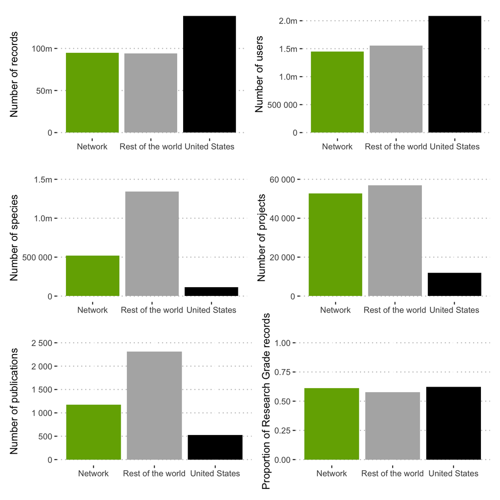

## Summary of the data for the Network members

| Country | Node | Observations | % Research Grade | Users | Species | Projects | Literature |
| --- | --- | --- | --- | --- | --- | --- | --- |
| Argentina | ArgentiNat | 2,283,654 | 0.699 | 30,460 | 20,263 | 2,353 | 76 |
| Australia | iNaturalistAU | 15,310,065 | 0.643 | 148,547 | 63,244 | 6,562 | 82 |
| Canada | iNaturalist.ca | 24,138,580 | 0.638 | 292,112 | 43,541 | 10,527 | 190 |
| Chile | iNaturalistCL | 1,193,958 | 0.611 | 29,064 | 13,545 | 1,008 | 39 |
| Colombia | NaturalistaCO | 2,495,386 | 0.416 | 67,609 | 36,995 | 2,547 | 105 |
| Costa Rica | NaturalistaCR | 2,216,679 | 0.536 | 45,966 | 26,873 | 1,254 | 21 |
| Ecuador | iNaturalistEc | 2,413,857 | 0.417 | 43,819 | 33,854 | 1,627 | 47 |
| Finland | iNaturalistFi | 1,665,904 | 0.641 | 34,021 | 13,304 | 288 | 14 |
| Greece | iNaturalistGR | 992,354 | 0.686 | 28,972 | 17,646 | 407 | 15 |
| Guatemala | iNaturalistGT | 227,053 | 0.454 | 10,742 | 10,845 | 715 | 23 |
| Israel | iNaturalistil | 516,876 | 0.683 | 8,306 | 10,348 | 395 | 3 |
| Luxembourg | iNaturalist.LU | 475,905 | 0.660 | 7,884 | 8,429 | 226 | 4 |
| Mexico | iNaturalistMX | 10,397,970 | 0.589 | 201,500 | 53,573 | 9,662 | 294 |
| New Zealand | iNaturalistNZ | 3,847,933 | 0.718 | 55,843 | 19,401 | 2,411 | 45 |
| Panama | iNaturalistPa | 947,824 | 0.465 | 21,628 | 22,008 | 658 | 7 |
| Portugal | BioDiversity4All | 2,817,785 | 0.678 | 46,636 | 19,567 | 1,432 | 48 |
| Spain | Natusfera | 6,340,708 | 0.662 | 96,442 | 35,069 | 2,807 | 77 |
| Sweden | iNaturalist.Se | 983,567 | 0.621 | 23,940 | 14,884 | 395 | 27 |
| Taiwan | iNaturalistTW | 4,930,701 | 0.659 | 70,854 | 25,206 | 2,639 | 15 |
| United Kingdom | iNaturalistUK | 10,223,232 | 0.674 | 177,716 | 24,351 | 4,356 | 34 |
| Uruguay | NaturalistaUY | 198,536 | 0.708 | 4,956 | 6,169 | 381 | 12 |

### Number of records on iNaturalist

```r
ids <- data_variables %>%
  select(country_name,node_name, n_records) %>%
  arrange(desc(n_records)) %>%
  with(which(!is.na(node_name)))

data_variables %>%
  select(country_name,node_name, n_records) %>%
  arrange(desc(n_records)) %>%
  mutate('#'= row_number()) %>% relocate('#') %>%
  rename(`Country` = country_name,
         `Node` = node_name,
         `Observations`=n_records) %>%
  kableExtra::kbl(digits=4, format.args = list(big.mark = ',')) %>%
  kableExtra::kable_material('striped') %>%
  kableExtra::row_spec(ids, bold = T, color = "white", background = "#228A22") %>%
  kableExtra::scroll_box(height = '600px')
```

| # | Country | Node | Observations |
| --- | --- | --- | --- |
| 1 | United States |  | 138,797,273 |
| 2 | Canada | iNaturalist.ca | 24,138,580 |
| 3 | Australia | iNaturalistAU | 15,310,065 |
| 4 | Russia |  | 12,128,611 |
| 5 | Mexico | iNaturalistMX | 10,397,970 |
| 6 | United Kingdom | iNaturalistUK | 10,223,232 |
| 7 | Germany |  | 7,541,023 |
| 8 | France |  | 7,265,947 |
| 9 | South Africa |  | 7,075,903 |
| 10 | Spain | Natusfera | 6,340,708 |
| 11 | Italy |  | 4,942,340 |
| 12 | India |  | 4,936,833 |
| 13 | Taiwan | iNaturalistTW | 4,930,701 |
| 14 | Brazil |  | 4,833,567 |
| 15 | New Zealand | iNaturalistNZ | 3,847,933 |
| 16 | Austria |  | 3,688,439 |
| 17 | Portugal | BioDiversity4All | 2,817,785 |
| 18 | China |  | 2,799,618 |
| 19 | Colombia | NaturalistaCO | 2,495,386 |
| 20 | Ecuador | iNaturalistEc | 2,413,857 |
| 21 | Argentina | ArgentiNat | 2,283,654 |
| 22 | Ukraine |  | 2,275,392 |
| 23 | Costa Rica | NaturalistaCR | 2,216,679 |
| 24 | Poland |  | 2,047,851 |
| 25 | Denmark |  | 2,047,299 |
| 26 | Czechia |  | 1,940,881 |
| 27 | Hong Kong SAR China |  | 1,736,608 |
| 28 | Finland | iNaturalistFi | 1,665,904 |
| 29 | Japan |  | 1,569,493 |
| 30 | Thailand |  | 1,390,892 |

[output cut: 167 more lines]

### Proportion of records that reach “Research Grade”

```r
ids <- data_variables %>%
  select(country_name,node_name, p_research_grade) %>%
  arrange(desc(p_research_grade)) %>%
  with(which(!is.na(node_name)))

data_variables %>%
  select(country_name, node_name, p_research_grade) %>%
  arrange(desc(p_research_grade)) %>%
  mutate('#'= row_number()) %>% relocate('#') %>%
  rename(`Country` = country_name,
         `Node` = node_name,
         `% Research Grade`=p_research_grade) %>%
  kableExtra::kbl(digits=4, format.args = list(big.mark = ',')) %>%
  kableExtra::kable_material('striped') %>%
  kableExtra::row_spec(ids, bold = T, color = "white", background = "#228A22") %>%
  kableExtra::scroll_box(height = '600px')
```

| # | Country | Node | % Research Grade |
| --- | --- | --- | --- |
| 1 | Vatican City |  | 0.8539 |
| 2 | Russia |  | 0.8126 |
| 3 | Nauru |  | 0.8016 |
| 4 | Belarus |  | 0.7945 |
| 5 | Mongolia |  | 0.7886 |
| 6 | Myanmar (Burma) |  | 0.7422 |
| 7 | North Korea |  | 0.7403 |
| 8 | Moldova |  | 0.7338 |
| 9 | Central African Republic |  | 0.7336 |
| 10 | Namibia |  | 0.7335 |
| 11 | Maldives |  | 0.7275 |
| 12 | Cuba |  | 0.7256 |
| 13 | Egypt |  | 0.7228 |
| 14 | Kiribati |  | 0.7225 |
| 15 | Monaco |  | 0.7219 |
| 16 | New Zealand | iNaturalistNZ | 0.7179 |
| 17 | Ukraine |  | 0.7093 |
| 18 | Uruguay | NaturalistaUY | 0.7084 |
| 19 | Djibouti |  | 0.7044 |
| 20 | Slovenia |  | 0.7039 |
| 21 | Niger |  | 0.7016 |
| 22 | Lithuania |  | 0.7004 |
| 23 | Argentina | ArgentiNat | 0.6992 |
| 24 | Bulgaria |  | 0.6934 |
| 25 | France |  | 0.6884 |
| 26 | Greece | iNaturalistGR | 0.6864 |
| 27 | Yemen |  | 0.6834 |
| 28 | Israel | iNaturalistil | 0.6828 |
| 29 | Malta |  | 0.6824 |
| 30 | Iceland |  | 0.6824 |

[output cut: 167 more lines]

### Number of users recording

```r
ids <- data_variables %>%
  select(country_name, node_name, n_users) %>%
  arrange(desc(n_users)) %>%
  with(which(!is.na(node_name)))

data_variables %>%
  select(country_name, node_name, n_users) %>%
  arrange(desc(n_users)) %>%
  mutate('#'= row_number()) %>% relocate('#') %>%
  rename(`Country` = country_name,
         `Node` = node_name,
         `Users recording on iNat`=n_users) %>%
  kableExtra::kbl(digits=4, format.args = list(big.mark = ',')) %>%
  kableExtra::kable_material('striped') %>%
  kableExtra::row_spec(ids, bold = T, color = "white", background = "#228A22") %>%
  kableExtra::scroll_box(height = '600px')
```

| # | Country | Node | Users recording on iNat |
| --- | --- | --- | --- |
| 1 | United States |  | 2,088,560 |
| 2 | Canada | iNaturalist.ca | 292,112 |
| 3 | Mexico | iNaturalistMX | 201,500 |
| 4 | United Kingdom | iNaturalistUK | 177,716 |
| 5 | France |  | 150,966 |
| 6 | Australia | iNaturalistAU | 148,547 |
| 7 | Italy |  | 108,451 |
| 8 | Germany |  | 102,416 |
| 9 | Spain | Natusfera | 96,442 |
| 10 | Brazil |  | 88,138 |
| 11 | Denmark |  | 80,329 |
| 12 | Taiwan | iNaturalistTW | 70,854 |
| 13 | Colombia | NaturalistaCO | 67,609 |
| 14 | India |  | 63,828 |
| 15 | New Zealand | iNaturalistNZ | 55,843 |
| 16 | Russia |  | 54,984 |
| 17 | South Africa |  | 52,084 |
| 18 | Portugal | BioDiversity4All | 46,636 |
| 19 | Costa Rica | NaturalistaCR | 45,966 |
| 20 | Ecuador | iNaturalistEc | 43,819 |
| 21 | Czechia |  | 42,365 |
| 22 | Austria |  | 38,542 |
| 23 | Netherlands |  | 35,455 |
| 24 | Japan |  | 34,078 |
| 25 | Finland | iNaturalistFi | 34,021 |
| 26 | Thailand |  | 32,319 |
| 27 | Argentina | ArgentiNat | 30,460 |
| 28 | Bolivia |  | 30,190 |
| 29 | Indonesia |  | 29,485 |
| 30 | Hong Kong SAR China |  | 29,299 |

[output cut: 167 more lines]

### Number of species recorded

```r
ids <- data_variables %>%
  select(country_name, node_name, n_species) %>%
  arrange(desc(n_species)) %>%
  with(which(!is.na(node_name)))

data_variables %>%
  select(country_name, node_name, n_species) %>%
  arrange(desc(n_species)) %>%
  mutate('#'= row_number()) %>% relocate('#') %>%
  rename(`Country` = country_name,
         `Node` = node_name,
         `Species`=n_species) %>%
  kableExtra::kbl(digits=4, format.args = list(big.mark = ',')) %>%
  kableExtra::kable_material('striped') %>%
  kableExtra::row_spec(ids, bold = T, color = "white", background = "#228A22") %>%
  kableExtra::scroll_box(height = '600px')
```

| # | Country | Node | Species |
| --- | --- | --- | --- |
| 1 | United States |  | 113,231 |
| 2 | Australia | iNaturalistAU | 63,244 |
| 3 | China |  | 54,177 |
| 4 | Mexico | iNaturalistMX | 53,573 |
| 5 | Brazil |  | 50,549 |
| 6 | Canada | iNaturalist.ca | 43,541 |
| 7 | South Africa |  | 40,847 |
| 8 | India |  | 38,842 |
| 9 | Russia |  | 37,779 |
| 10 | Colombia | NaturalistaCO | 36,995 |
| 11 | France |  | 36,635 |
| 12 | Spain | Natusfera | 35,069 |
| 13 | Ecuador | iNaturalistEc | 33,854 |
| 14 | Indonesia |  | 30,450 |
| 15 | Italy |  | 29,220 |
| 16 | Germany |  | 28,950 |
| 17 | Peru |  | 28,064 |
| 18 | Japan |  | 27,915 |
| 19 | Malaysia |  | 27,711 |
| 20 | Thailand |  | 27,009 |
| 21 | Costa Rica | NaturalistaCR | 26,873 |
| 22 | Taiwan | iNaturalistTW | 25,206 |
| 23 | United Kingdom | iNaturalistUK | 24,351 |
| 24 | Austria |  | 22,540 |
| 25 | Panama | iNaturalistPa | 22,008 |
| 26 | Argentina | ArgentiNat | 20,263 |
| 27 | Portugal | BioDiversity4All | 19,567 |
| 28 | New Zealand | iNaturalistNZ | 19,401 |
| 29 | Ukraine |  | 18,403 |
| 30 | Philippines |  | 18,393 |

[output cut: 167 more lines]

### Number of projects created

```r
ids <- data_variables %>%
  select(country_name, node_name, n_projects) %>%
  arrange(desc(n_projects)) %>%
  with(which(!is.na(node_name)))

data_variables %>%
  select(country_name, node_name, n_projects) %>%
  arrange(desc(n_projects)) %>%
  mutate('#'= row_number()) %>% relocate('#') %>%
  rename(`Country` = country_name,
         `Node` = node_name,
         `Projects created on iNat`=n_projects) %>%
  kableExtra::kbl(digits=4, format.args = list(big.mark = ',')) %>%
  kableExtra::kable_material('striped') %>%
  kableExtra::row_spec(ids, bold = T, color = "white", background = "#228A22") %>%
  kableExtra::scroll_box(height = '600px')
```

| # | Country | Node | Projects created on iNat |
| --- | --- | --- | --- |
| 1 | United States |  | 12,004 |
| 2 | Canada | iNaturalist.ca | 10,527 |
| 3 | Mexico | iNaturalistMX | 9,662 |
| 4 | Australia | iNaturalistAU | 6,562 |
| 5 | Russia |  | 5,813 |
| 6 | United Kingdom | iNaturalistUK | 4,356 |
| 7 | Brazil |  | 4,270 |
| 8 | India |  | 3,397 |
| 9 | Spain | Natusfera | 2,807 |
| 10 | France |  | 2,640 |
| 11 | Taiwan | iNaturalistTW | 2,639 |
| 12 | Colombia | NaturalistaCO | 2,547 |
| 13 | Germany |  | 2,501 |
| 14 | South Africa |  | 2,421 |
| 15 | New Zealand | iNaturalistNZ | 2,411 |
| 16 | Argentina | ArgentiNat | 2,353 |
| 17 | Hong Kong SAR China |  | 2,348 |
| 18 | Italy |  | 1,913 |
| 19 | Ecuador | iNaturalistEc | 1,627 |
| 20 | Portugal | BioDiversity4All | 1,432 |
| 21 | Costa Rica | NaturalistaCR | 1,254 |
| 22 | Peru |  | 1,215 |
| 23 | Chile | iNaturalistCL | 1,008 |
| 24 | Austria |  | 886 |
| 25 | Thailand |  | 885 |
| 26 | China |  | 860 |
| 27 | Ireland |  | 778 |
| 28 | Indonesia |  | 775 |
| 29 | Botswana |  | 747 |
| 30 | Ukraine |  | 737 |

[output cut: 167 more lines]

### Number of peer-reviewed publications in GBIF using iNat data

```r
ids <- data_variables %>%
  select(country_name, node_name, n_literature) %>%
  arrange(desc(n_literature)) %>%
  with(which(!is.na(node_name)))

data_variables %>%
  select(country_name, node_name, n_literature) %>%
  arrange(desc(n_literature)) %>%
  mutate('#'= row_number()) %>% relocate('#') %>%
  rename(`Country` = country_name,
         `Node` = node_name,
         `Literature`=n_literature) %>%
  kableExtra::kbl(digits=4, format.args = list(big.mark = ',')) %>%
  kableExtra::kable_material('striped') %>%
  kableExtra::row_spec(ids, bold = T, color = "white", background = "#228A22") %>%
  kableExtra::scroll_box(height = '600px')
```

| # | Country | Node | Literature |
| --- | --- | --- | --- |
| 1 | United States |  | 527 |
| 2 | Mexico | iNaturalistMX | 294 |
| 3 | China |  | 244 |
| 4 | Brazil |  | 200 |
| 5 | Canada | iNaturalist.ca | 190 |
| 6 | India |  | 132 |
| 7 | Russia |  | 107 |
| 8 | Colombia | NaturalistaCO | 105 |
| 9 | Australia | iNaturalistAU | 82 |
| 10 | South Africa |  | 79 |
| 11 | Spain | Natusfera | 77 |
| 12 | Argentina | ArgentiNat | 76 |
| 13 | Indonesia |  | 64 |
| 14 | Italy |  | 53 |
| 15 | Peru |  | 48 |
| 16 | Portugal | BioDiversity4All | 48 |
| 17 | Ecuador | iNaturalistEc | 47 |
| 18 | Ukraine |  | 46 |
| 19 | New Zealand | iNaturalistNZ | 45 |
| 20 | South Korea |  | 42 |
| 21 | Chile | iNaturalistCL | 39 |
| 22 | Turkey |  | 37 |
| 23 | Norway |  | 35 |
| 24 | United Kingdom | iNaturalistUK | 34 |
| 25 | Japan |  | 32 |
| 26 | Germany |  | 29 |
| 27 | Sweden | iNaturalist.Se | 27 |
| 28 | Madagascar |  | 26 |
| 29 | Benin |  | 25 |
| 30 | Nepal |  | 25 |

[output cut: 167 more lines]

## Associations between variables

### Population of the country

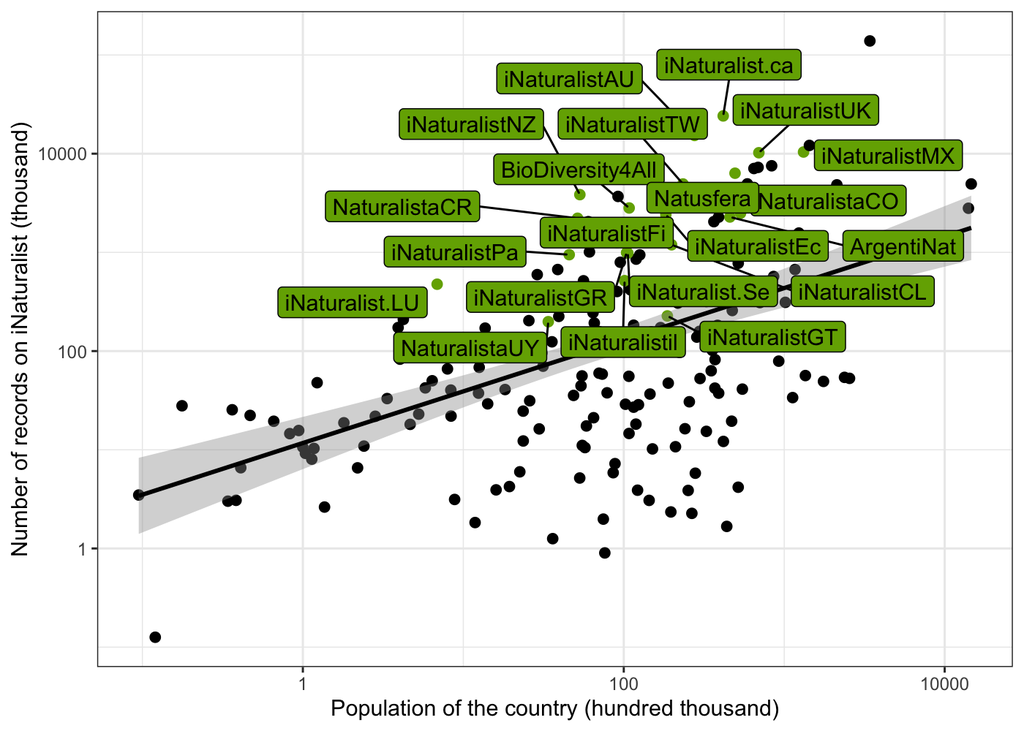

Number of records on iNaturalist vs Population of the country

```r
## records
ggplot(data_variables %>% mutate(has_node = as.character(has_node)),
       aes(population/100000, n_records/1000, label = node_name)) +
  geom_point(aes(col=has_node), size=2, show.legend = F) +
  scale_color_manual(values = c('black', '#74AC00')) +
  geom_smooth(method='lm', colour = 'black') +
  # # geom_abline(lwd = 1.5, linetype = 'dashed', col = 'orange') +
  geom_label_repel(aes(fill=has_node),
                   colour = "black", #fontface = "bold",
                   segment.color = 'black',
                   show.legend = F, max.overlaps= Inf) +
  scale_fill_manual(values = c('#F7F7F7', '#74AC00')) +
  labs(x='Population of the country (hundred thousand)',
       y='Number of records on iNaturalist (thousand)') +
  scale_x_log10() + scale_y_log10() +
  theme_bw()
```

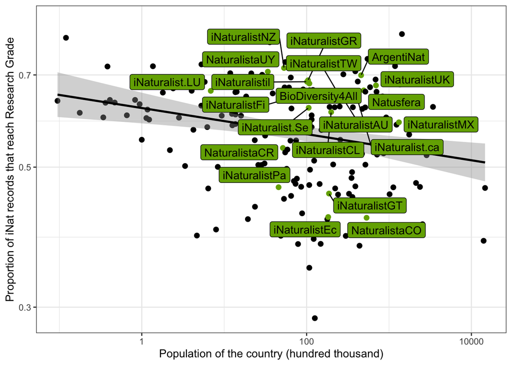

Proportion of Research Grade iNat records vs Population of the country

```r
## records in research_grade
ggplot(data_variables %>% mutate(has_node = as.character(has_node)),
       aes(population/100000, p_research_grade, label = node_name)) +
  geom_point(aes(col=has_node), size=2, show.legend = F) +
  scale_color_manual(values = c('black', '#74AC00')) +
  geom_smooth(method='lm', colour = 'black') +
  # geom_abline(lwd = 1.5, linetype = 'dashed', col = 'orange') +
  geom_label_repel(aes(fill=has_node),
                   colour = "black", #fontface = "bold",
                   segment.color = 'black',
                   show.legend = F, max.overlaps= Inf) +
  scale_fill_manual(values = c('#F7F7F7', '#74AC00')) +
  labs(x='Population of the country (hundred thousand)',
       y='Proportion of iNat records that reach Research Grade') +
  scale_x_log10() + scale_y_log10() +
  theme_bw()
```

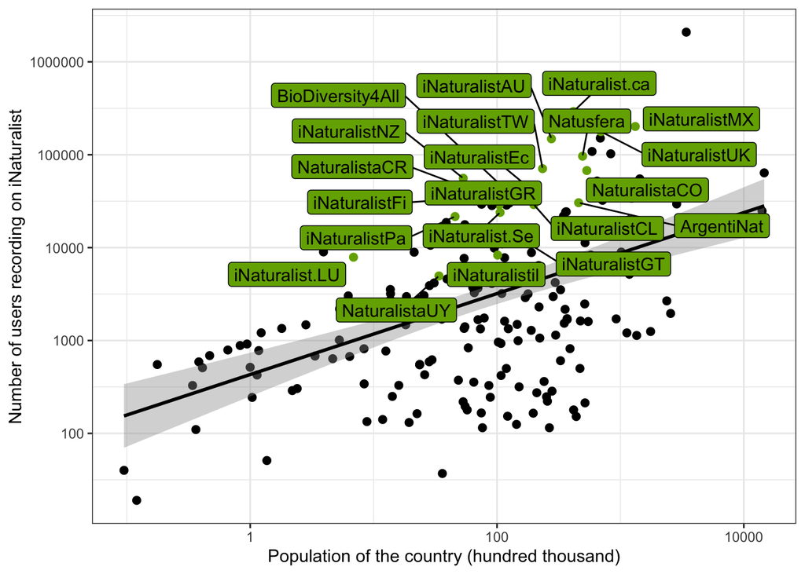

Number of users recording on iNaturalist vs Population of the country

```r
## users
ggplot(data_variables %>% mutate(has_node = as.character(has_node)),
       aes(population/100000, n_users, label = node_name)) +
  geom_point(aes(col=has_node), size=2, show.legend = F) +
  scale_color_manual(values = c('black', '#74AC00')) +
  geom_smooth(method='lm', col= 'black') +
  # # geom_abline(lwd = 1.5, linetype = 'dashed', col = 'orange') +
  geom_label_repel(aes(fill=has_node),
                   colour = "black", #fontface = "bold",
                   segment.color = 'black',
                   show.legend = F, max.overlaps= Inf) +
  scale_fill_manual(values = c('#F7F7F7', '#74AC00')) +
  labs(x='Population of the country (hundred thousand)',
       y='Number of users recording on iNaturalist') +
  scale_x_log10() + scale_y_log10() +
  theme_bw()
```

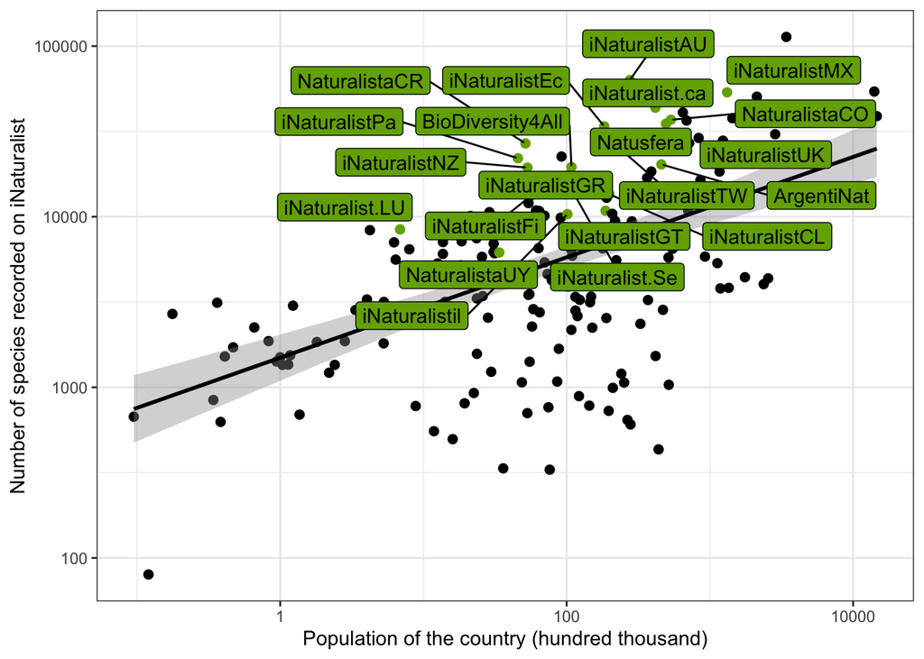

Number of species recorded on iNaturalist vs Population of the country

```r
## users
ggplot(data_variables %>% mutate(has_node = as.character(has_node)),
       aes(population/100000, n_species, label = node_name)) +
  geom_point(aes(col=has_node), size=2, show.legend = F) +
  scale_color_manual(values = c('black', '#74AC00')) +
  geom_smooth(method='lm', col= 'black') +
  # geom_abline(lwd = 1.5, linetype = 'dashed', col = 'orange') +
  geom_label_repel(aes(fill=has_node),
                   colour = "black", #fontface = "bold",
                   segment.color = 'black',
                   show.legend = F, max.overlaps= Inf) +
  scale_fill_manual(values = c('#F7F7F7', '#74AC00')) +
  labs(x='Population of the country (hundred thousand)',
       y='Number of species recorded on iNaturalist') +
  scale_x_log10() + scale_y_log10() +
  theme_bw()
```

### Area of the country in km<sup>2</sup>

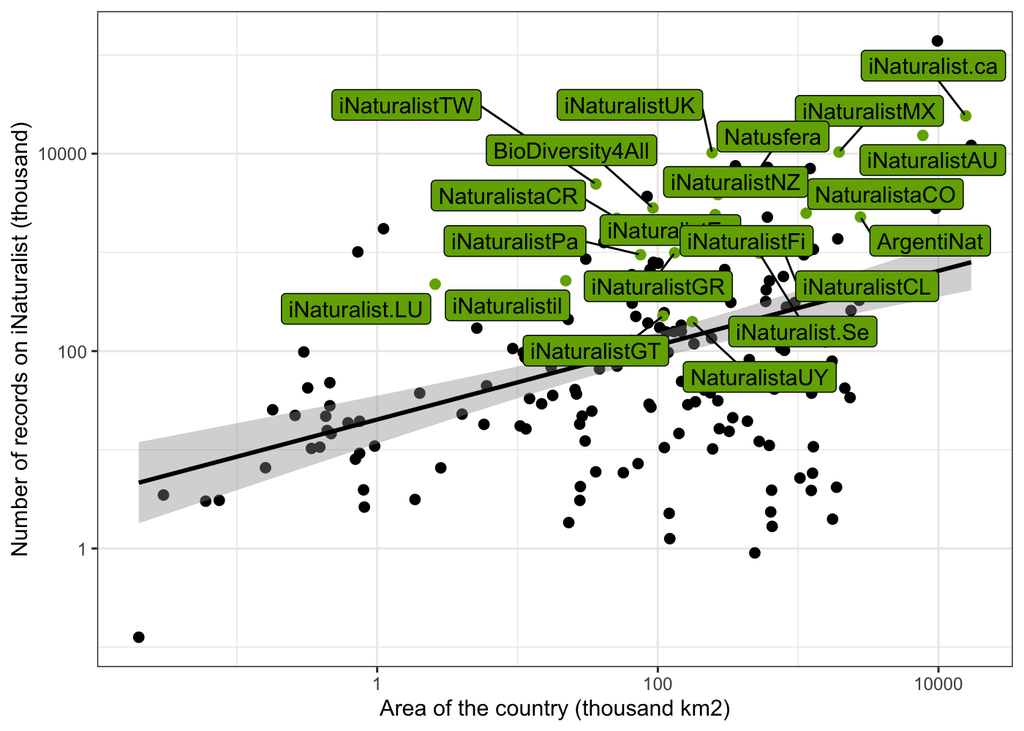

Number of records on iNaturalist vs Area of the country

```r
## records
ggplot(data_variables %>% mutate(has_node = as.character(has_node)),
       aes(area/1000,n_records/1000, label = node_name)) +
  geom_point(aes(col=has_node), size=2, show.legend = F) +
  scale_color_manual(values = c('black', '#74AC00')) +
  geom_smooth(method='lm', colour = 'black') +
  # geom_abline(lwd = 1.5, linetype = 'dashed', col = 'orange') +
  geom_label_repel(aes(fill=has_node),
                   colour = "black", #fontface = "bold",
                   segment.color = 'black',
                   show.legend = F, max.overlaps= Inf) +
  scale_fill_manual(values = c('#F7F7F7', '#74AC00')) +
  labs(x='Area of the country (thousand km2)',
       y='Number of records on iNaturalist (thousand)') +
  scale_x_log10() + scale_y_log10() +
  theme_bw()
```

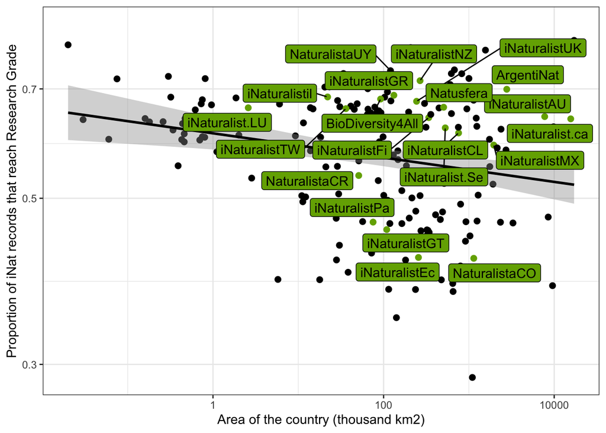

Proportion of Research Grade iNat records vs Area of the country

```r
## records in research grade
ggplot(data_variables %>% mutate(has_node = as.character(has_node)),
       aes(area/1000, p_research_grade, label = node_name)) +
  geom_point(aes(col=has_node), size=2, show.legend = F) +
  scale_color_manual(values = c('black', '#74AC00')) +
  geom_smooth(method='lm', colour = 'black') +
  # geom_abline(lwd = 1.5, linetype = 'dashed', col = 'orange') +
  geom_label_repel(aes(fill=has_node),
                   colour = "black", #fontface = "bold",
                   segment.color = 'black',
                   show.legend = F, max.overlaps= Inf) +
  scale_fill_manual(values = c('#F7F7F7', '#74AC00')) +
  labs(x='Area of the country (thousand km2)',
       y='Proportion of iNat records that reach Research Grade') +
  scale_x_log10() + scale_y_log10() +
  theme_bw()
```

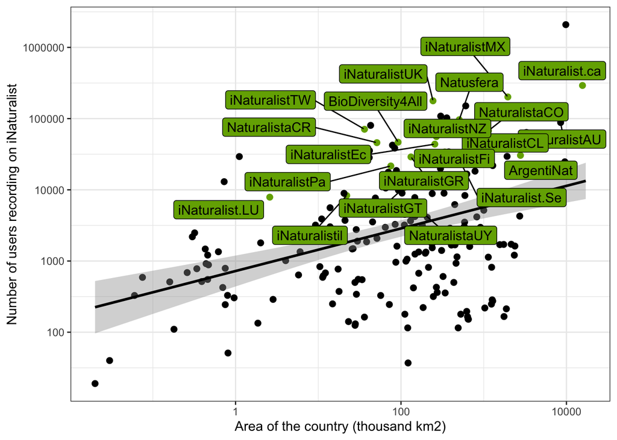

Number of users recording on iNaturalist vs Area of the country

```r
## users
ggplot(data_variables %>% mutate(has_node = as.character(has_node)),
       aes(area/1000, n_users, label = node_name)) +
  geom_point(aes(col=has_node), size=2, show.legend = F) +
  scale_color_manual(values = c('black', '#74AC00')) +
  geom_smooth(method='lm', colour = 'black') +
  # geom_abline(lwd = 1.5, linetype = 'dashed', col = 'orange') +
  geom_label_repel(aes(fill=has_node),
                   colour = "black", #fontface = "bold",
                   segment.color = 'black',
                   show.legend = F, max.overlaps= Inf) +
  scale_fill_manual(values = c('#F7F7F7', '#74AC00')) +
  labs(x='Area of the country (thousand km2)',
       y='Number of users recording on iNaturalist') +
  scale_x_log10() + scale_y_log10() +
  theme_bw()
```

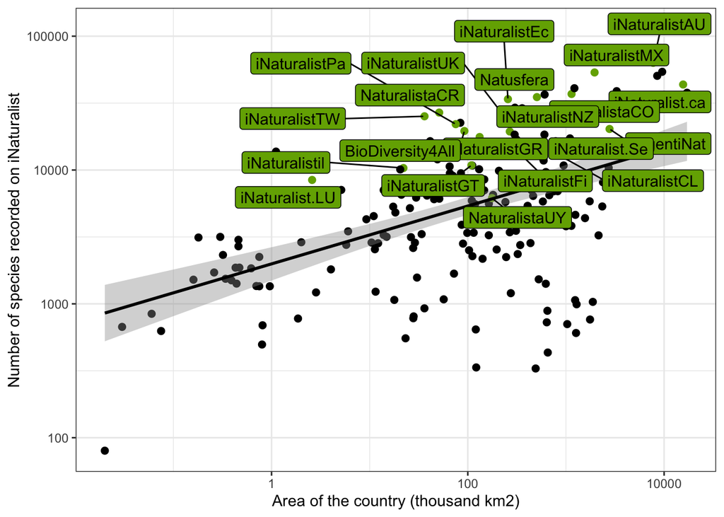

Number of species recorded on iNaturalist vs Area of the country

```r
## species
ggplot(data_variables %>% mutate(has_node = as.character(has_node)),
       aes(area/1000, n_species, label = node_name)) +
  geom_point(aes(col=has_node), size=2, show.legend = F) +
  scale_color_manual(values = c('black', '#74AC00')) +
  geom_smooth(method='lm', colour = 'black') +
  # geom_abline(lwd = 1.5, linetype = 'dashed', col = 'orange') +
  geom_label_repel(aes(fill=has_node),
                   colour = "black", #fontface = "bold",
                   segment.color = 'black',
                   show.legend = F, max.overlaps= Inf) +
  scale_fill_manual(values = c('#F7F7F7', '#74AC00')) +
  labs(x='Area of the country (thousand km2)',
       y='Number of species recorded on iNaturalist') +
  scale_x_log10() + scale_y_log10() +
  theme_bw()
```

### GDP per capita

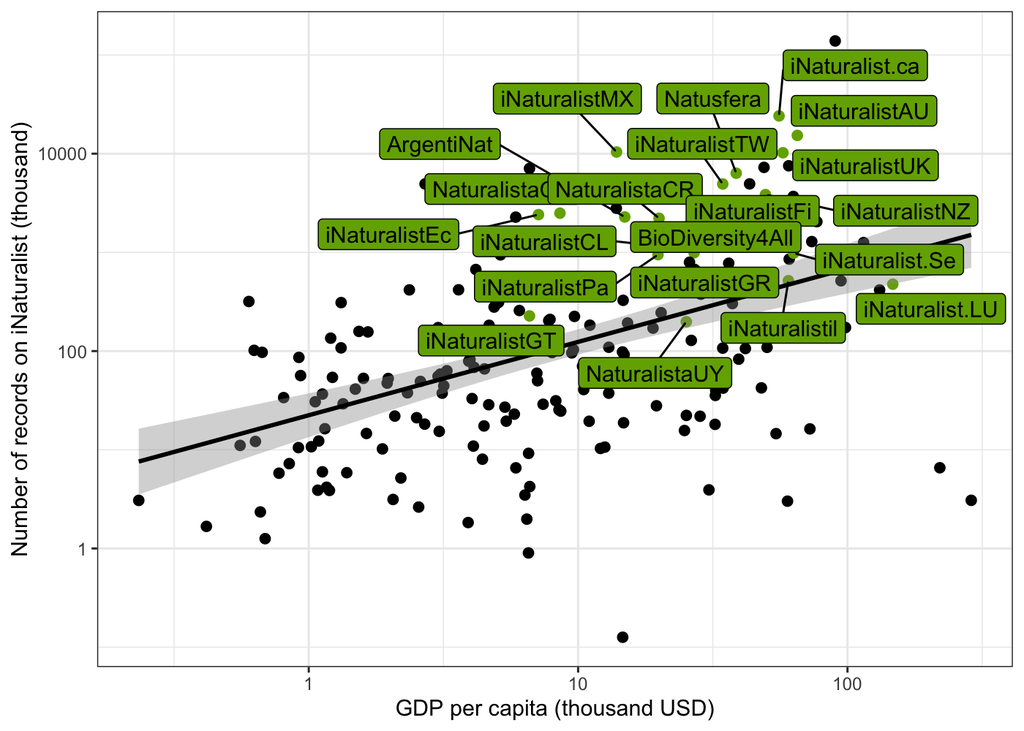

Number of records on iNaturalist vs country’s GDP per capita

```r
## records
ggplot(data_variables %>% mutate(has_node = as.character(has_node)),
       aes(gdp_per_capita/1000, n_records/1000, label = node_name)) +
  geom_point(aes(col=has_node), size=2, show.legend = F) +
  scale_color_manual(values = c('black', '#74AC00')) +
  geom_smooth(method='lm', colour = 'black') +
  # geom_abline(lwd = 1.5, linetype = 'dashed', col = 'orange') +
  geom_label_repel(aes(fill=has_node),
                   colour = "black", #fontface = "bold",
                   segment.color = 'black',
                   show.legend = F, max.overlaps= Inf) +
  scale_fill_manual(values = c('#F7F7F7', '#74AC00')) +
  labs(x='GDP per capita (thousand USD)',
       y='Number of records on iNaturalist (thousand)') +
  scale_x_log10() + scale_y_log10() +
  theme_bw()
```

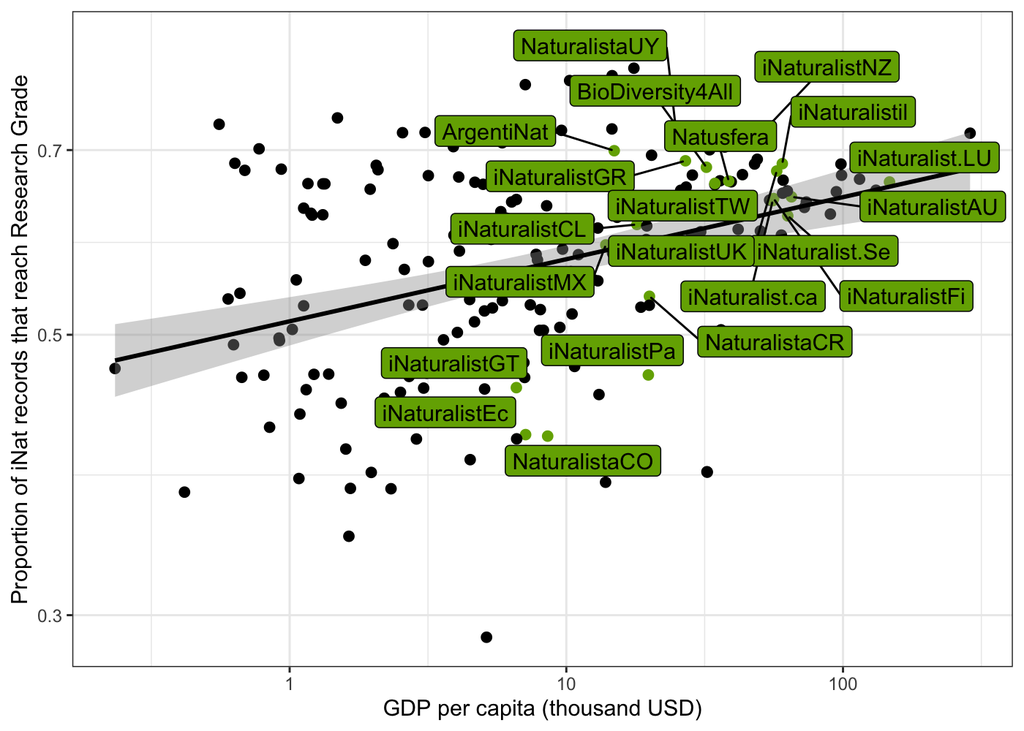

Proportion of Research Grade iNat records vs country’s GDP per capita

```r
## records in research grade
ggplot(data_variables %>% mutate(has_node = as.character(has_node)),
       aes(gdp_per_capita/1000, p_research_grade, label = node_name)) +
  geom_point(aes(col=has_node), size=2, show.legend = F) +
  scale_color_manual(values = c('black', '#74AC00')) +
  geom_smooth(method='lm', colour = 'black') +
  # geom_abline(lwd = 1.5, linetype = 'dashed', col = 'orange') +
  geom_label_repel(aes(fill=has_node),
                   colour = "black", #fontface = "bold",
                   segment.color = 'black',
                   show.legend = F, max.overlaps= Inf) +
  scale_fill_manual(values = c('#F7F7F7', '#74AC00')) +
  labs(x='GDP per capita (thousand USD)',
       y='Proportion of iNat records that reach Research Grade') +
  scale_x_log10() + scale_y_log10() +
  theme_bw()
```

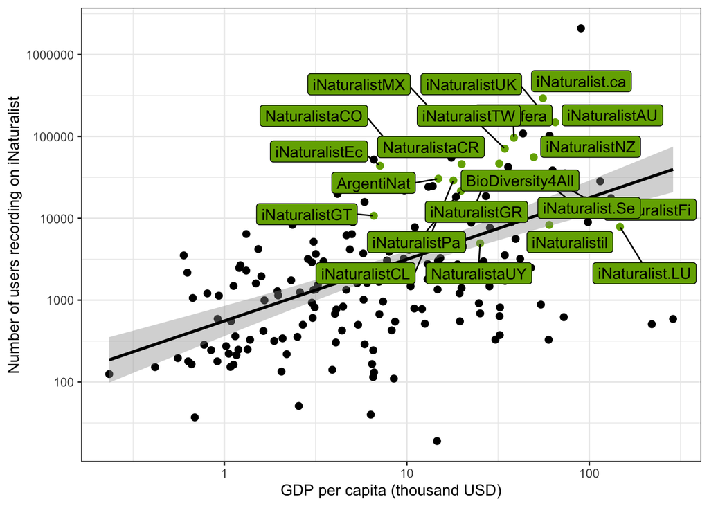

Number of users recording on iNaturalist vs GDP per capita

```r
## users
ggplot(data_variables %>% mutate(has_node = as.character(has_node)),
       aes(gdp_per_capita/1000, n_users, label = node_name)) +
  geom_point(aes(col=has_node), size=2, show.legend = F) +
  scale_color_manual(values = c('black', '#74AC00')) +
  geom_smooth(method='lm', colour = 'black') +
  # geom_abline(lwd = 1.5, linetype = 'dashed', col = 'orange') +
  geom_label_repel(aes(fill=has_node),
                   colour = "black", #fontface = "bold",
                   segment.color = 'black',
                   show.legend = F, max.overlaps= Inf) +
  scale_fill_manual(values = c('#F7F7F7', '#74AC00')) +
  labs(x='GDP per capita (thousand USD)',
       y='Number of users recording on iNaturalist') +
  scale_x_log10() + scale_y_log10() +
  theme_bw()
```

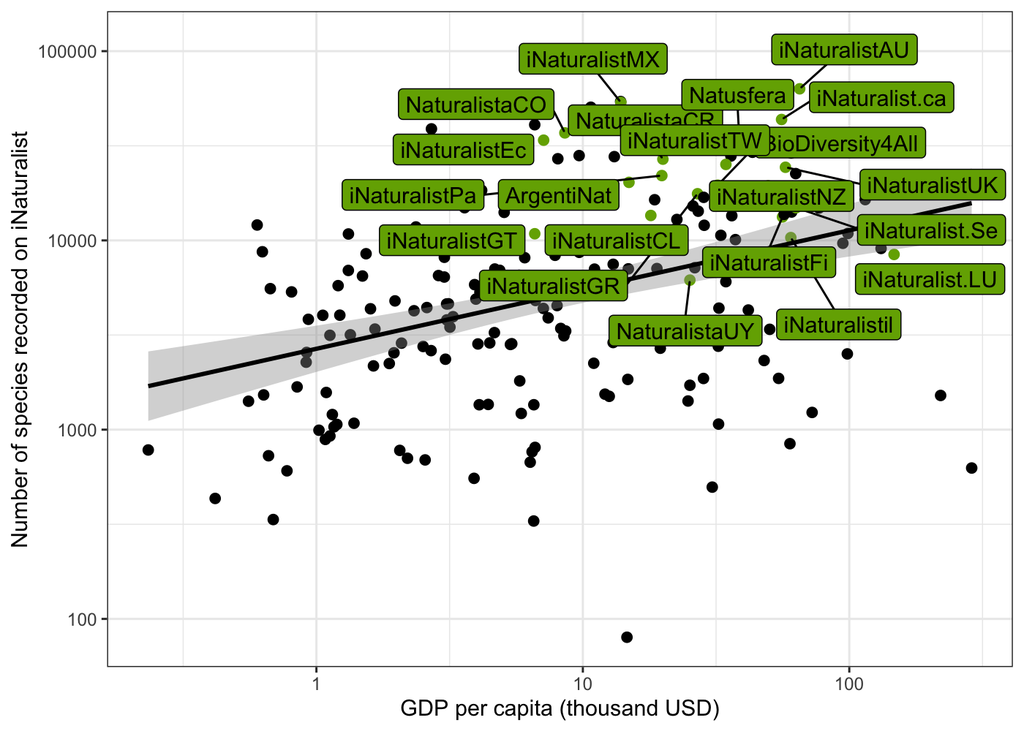

Number of species recorded on iNaturalist vs GDP per capita

```r
## species
ggplot(data_variables %>% mutate(has_node = as.character(has_node)),
       aes(gdp_per_capita/1000, n_species, label = node_name)) +
  geom_point(aes(col=has_node), size=2, show.legend = F) +
  scale_color_manual(values = c('black', '#74AC00')) +
  geom_smooth(method='lm', colour = 'black') +
  # geom_abline(lwd = 1.5, linetype = 'dashed', col = 'orange') +
  geom_label_repel(aes(fill=has_node),
                   colour = "black", #fontface = "bold",
                   segment.color = 'black',
                   show.legend = F, max.overlaps= Inf) +
  scale_fill_manual(values = c('#F7F7F7', '#74AC00')) +
  labs(x='GDP per capita (thousand USD)',
       y='Number of species recorded on iNaturalist') +
  scale_x_log10() + scale_y_log10() +
  theme_bw()
```

### % of the GDP of the country dedicated to research

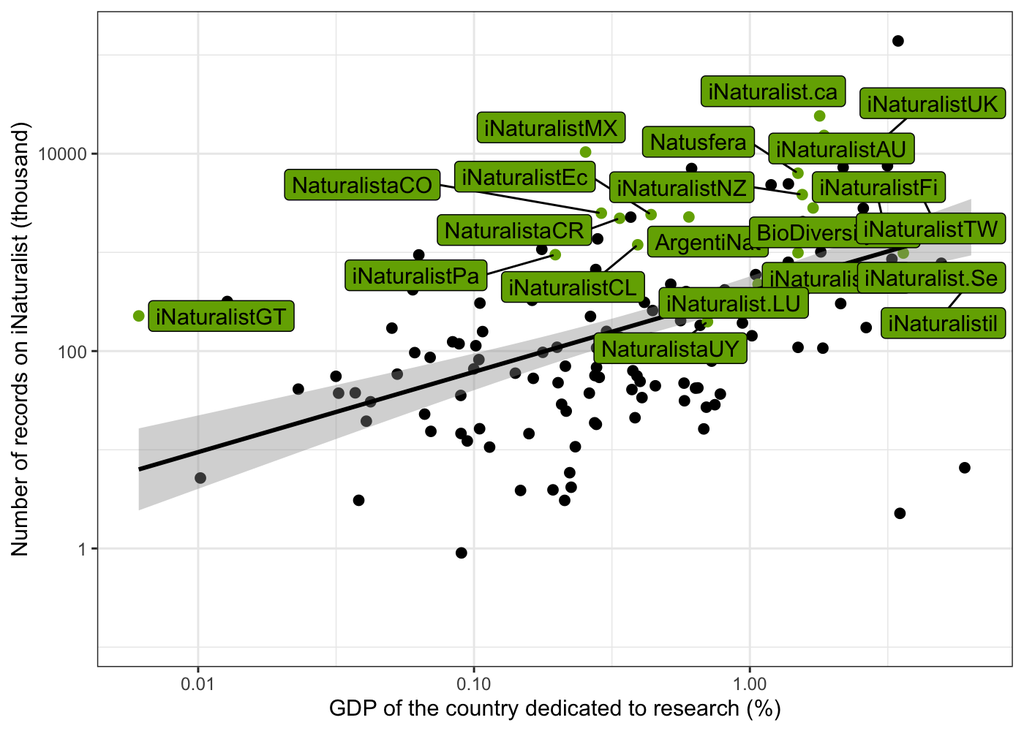

Number of records on iNaturalist vs % of the country’s GDP dedicated to research

```r
## records
ggplot(data_variables %>% mutate(has_node = as.character(has_node)),
       aes(gdp_in_research, n_records/1000, label = node_name)) +
  geom_point(aes(col=has_node), size=2, show.legend = F) +
  scale_color_manual(values = c('black', '#74AC00')) +
  geom_smooth(method='lm', colour = 'black') +
  # geom_abline(lwd = 1.5, linetype = 'dashed', col = 'orange') +
  geom_label_repel(aes(fill=has_node),
                   colour = "black", #fontface = "bold",
                   segment.color = 'black',
                   show.legend = F, max.overlaps= Inf) +
  scale_fill_manual(values = c('#F7F7F7', '#74AC00')) +
  labs(x='GDP of the country dedicated to research (%)',
       y='Number of records on iNaturalist (thousand)') +
  scale_x_log10() + scale_y_log10() +
  theme_bw()
```

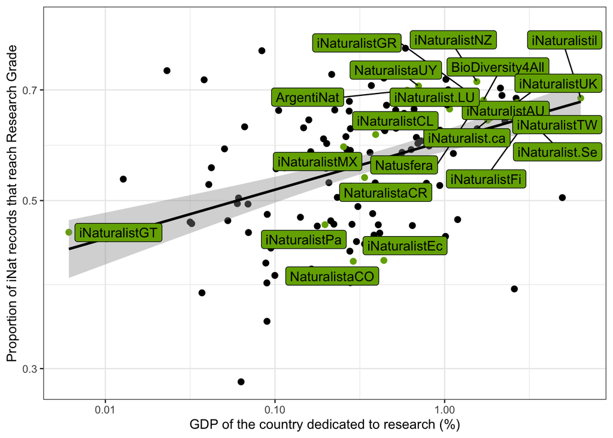

Proportion of Research Grade iNat records vs % of the country’s GDP dedicated to research

```r
## records in research grade
ggplot(data_variables %>% mutate(has_node = as.character(has_node)),
       aes(gdp_in_research, p_research_grade, label = node_name)) +
  geom_point(aes(col=has_node), size=2, show.legend = F) +
  scale_color_manual(values = c('black', '#74AC00')) +
  geom_smooth(method='lm', colour = 'black') +
  # geom_abline(lwd = 1.5, linetype = 'dashed', col = 'orange') +
  geom_label_repel(aes(fill=has_node),
                   colour = "black", #fontface = "bold",
                   segment.color = 'black',
                   show.legend = F, max.overlaps= Inf) +
  scale_fill_manual(values = c('#F7F7F7', '#74AC00')) +
  labs(x='GDP of the country dedicated to research (%)',
       y='Proportion of iNat records that reach Research Grade') +
  scale_x_log10() + scale_y_log10() +
  theme_bw()
```

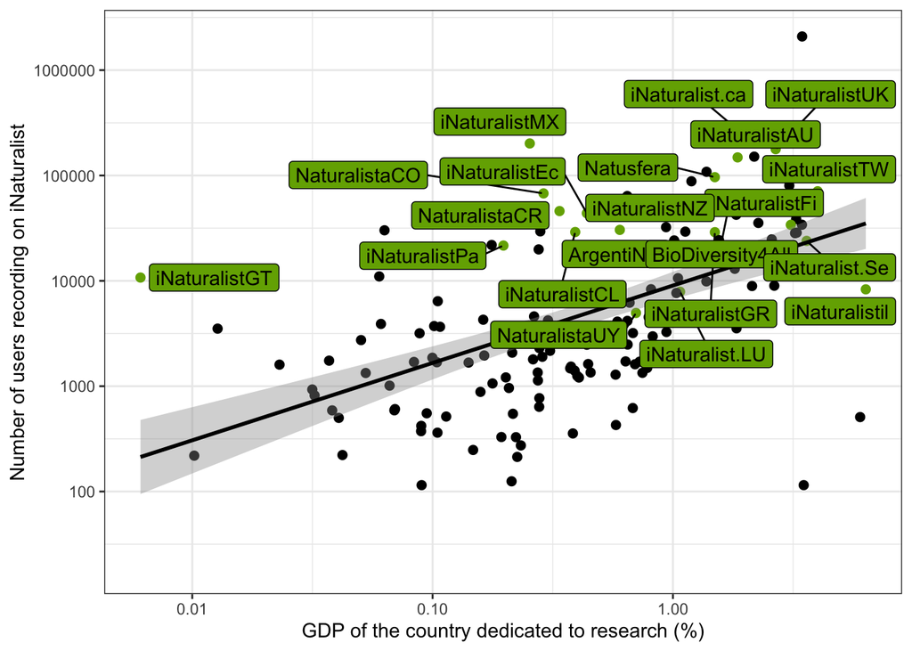

Number of users recording on iNaturalist vs % of the country’s GDP dedicated to research

```r
## users
ggplot(data_variables %>% mutate(has_node = as.character(has_node)),
       aes(gdp_in_research,n_users, label = node_name)) +
  geom_point(aes(col=has_node), size=2, show.legend = F) +
  scale_color_manual(values = c('black', '#74AC00')) +
  geom_smooth(method='lm', colour = 'black') +
  # geom_abline(lwd = 1.5, linetype = 'dashed', col = 'orange') +
  geom_label_repel(aes(fill=has_node),
                   colour = "black", #fontface = "bold",
                   segment.color = 'black',
                   show.legend = F, max.overlaps= Inf) +
  scale_fill_manual(values = c('#F7F7F7', '#74AC00')) +
  labs(x='GDP of the country dedicated to research (%)',
       y='Number of users recording on iNaturalist') +
  scale_x_log10() + scale_y_log10() +
  theme_bw()
```

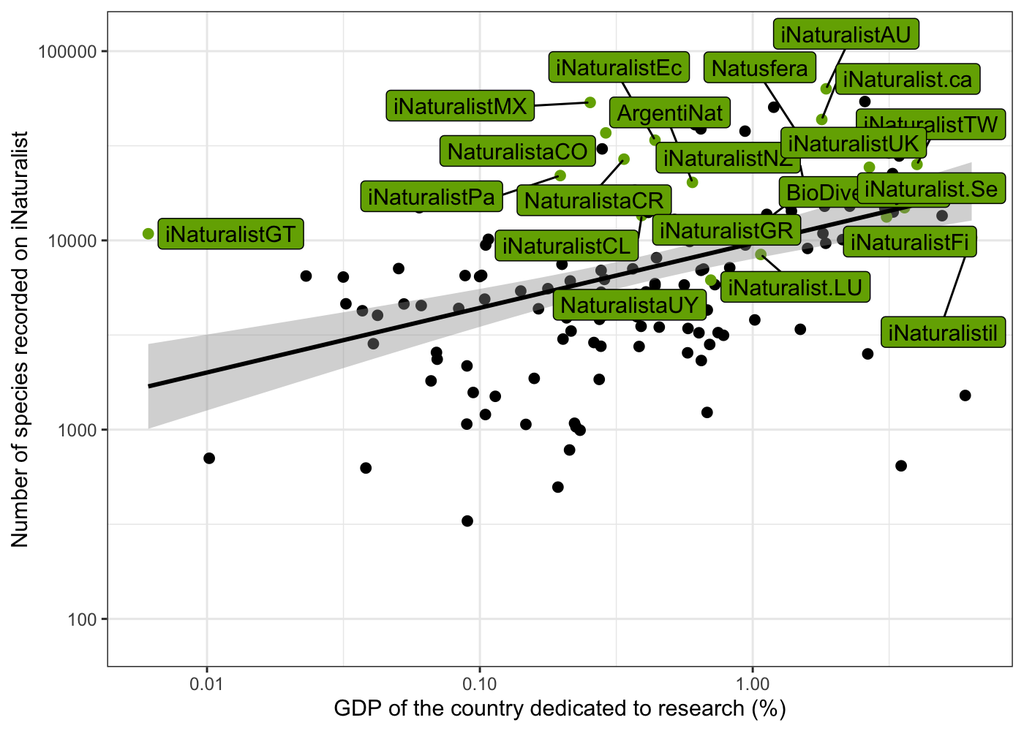

Number of species recorded on iNaturalist vs % of the country’s GDP dedicated to research

```r
## species
ggplot(data_variables %>% mutate(has_node = as.character(has_node)),
       aes(gdp_in_research,n_species, label = node_name)) +
  geom_point(aes(col=has_node), size=2, show.legend = F) +
  scale_color_manual(values = c('black', '#74AC00')) +
  geom_smooth(method='lm', colour = 'black') +
  # geom_abline(lwd = 1.5, linetype = 'dashed', col = 'orange') +
  geom_label_repel(aes(fill=has_node),
                   colour = "black", #fontface = "bold",
                   segment.color = 'black',
                   show.legend = F, max.overlaps= Inf) +
  scale_fill_manual(values = c('#F7F7F7', '#74AC00')) +
  labs(x='GDP of the country dedicated to research (%)',
       y='Number of species recorded on iNaturalist') +
  scale_x_log10() + scale_y_log10() +
  theme_bw()
```

### Country’s centroid latitude

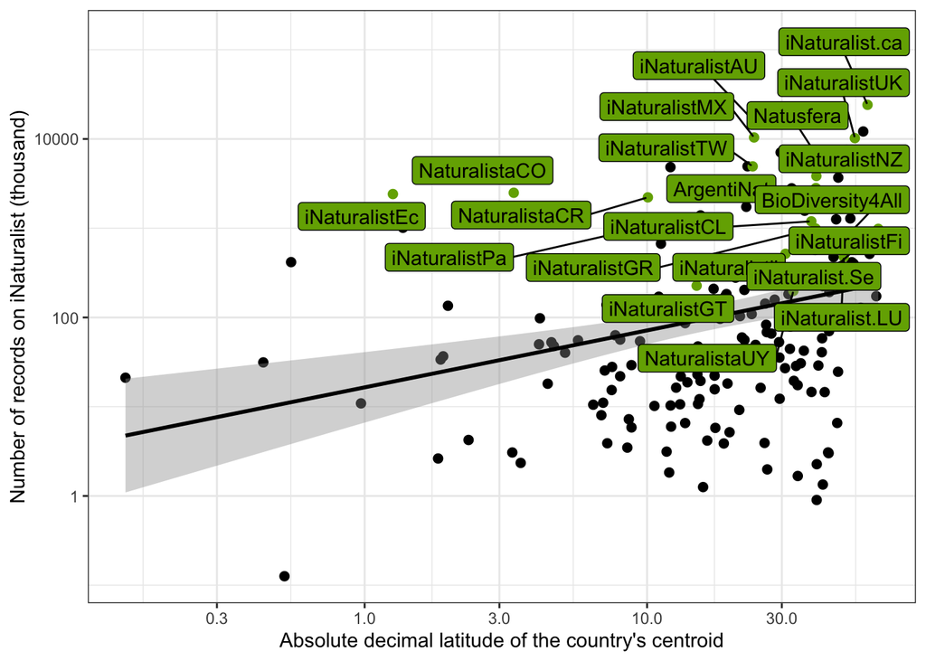

Number of records on iNaturalist vs country’s centroid latitude

```r
## records
ggplot(data_variables %>% mutate(has_node = as.character(has_node)),
       aes(abs(latitude), n_records/1000, label = node_name)) +
  geom_point(aes(col=has_node), size=2, show.legend = F) +
  scale_color_manual(values = c('black', '#74AC00')) +
  geom_smooth(method='lm', colour = 'black') +
  # geom_abline(lwd = 1.5, linetype = 'dashed', col = 'orange') +
  geom_label_repel(aes(fill=has_node),
                   colour = "black", #fontface = "bold",
                   segment.color = 'black',
                   show.legend = F, max.overlaps= Inf) +
  scale_fill_manual(values = c('#F7F7F7', '#74AC00')) +
  labs(x='Absolute decimal latitude of the country\'s centroid',
       y='Number of records on iNaturalist (thousand)') +
  scale_x_log10() + scale_y_log10() +
  theme_bw()
```

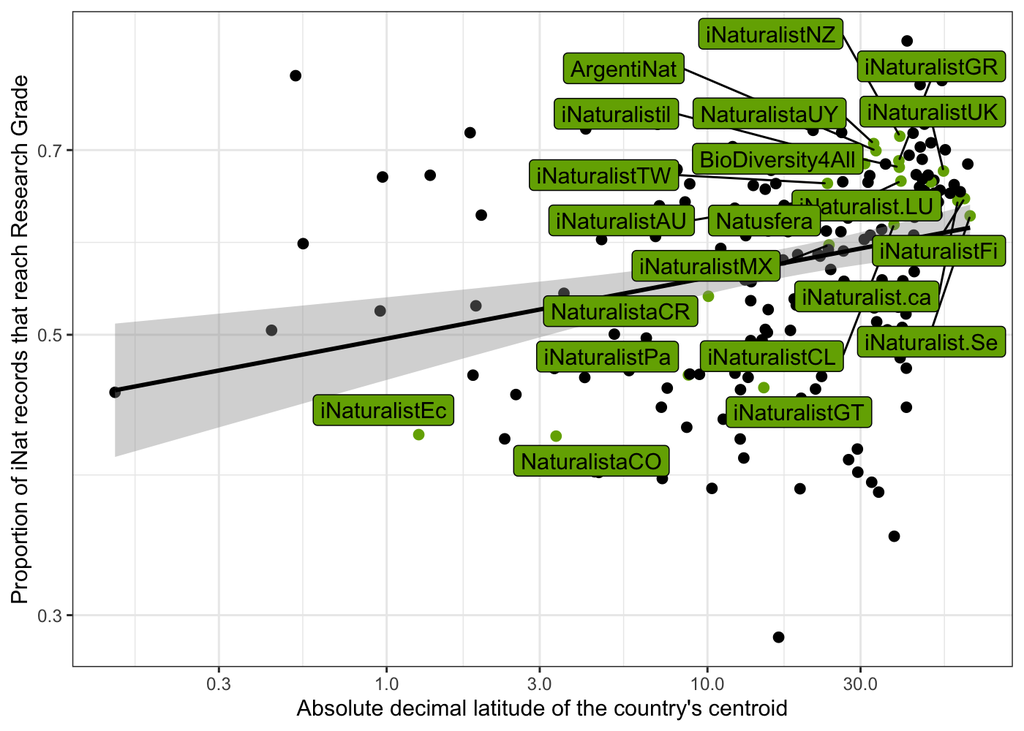

Proportion of Research Grade iNat records vs country’s centroid latitude

```r
## records in research grade
ggplot(data_variables %>% mutate(has_node = as.character(has_node)),
       aes(abs(latitude), p_research_grade, label = node_name)) +
  geom_point(aes(col=has_node), size=2, show.legend = F) +
  scale_color_manual(values = c('black', '#74AC00')) +
  geom_smooth(method='lm', colour = 'black') +
  # geom_abline(lwd = 1.5, linetype = 'dashed', col = 'orange') +
  geom_label_repel(aes(fill=has_node),
                   colour = "black", #fontface = "bold",
                   segment.color = 'black',
                   show.legend = F, max.overlaps= Inf) +
  scale_fill_manual(values = c('#F7F7F7', '#74AC00')) +
  labs(x='Absolute decimal latitude of the country\'s centroid',
       y='Proportion of iNat records that reach Research Grade') +
  scale_x_log10() + scale_y_log10() +
  theme_bw()
```

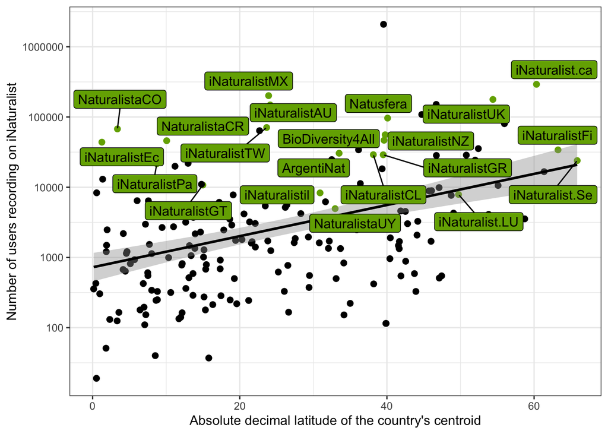

Number of users recording on iNaturalist vs country’s centroid latitude

```r
## users
ggplot(data_variables %>% mutate(has_node = as.character(has_node)),
       aes(abs(latitude), n_users, label = node_name)) +
  geom_point(aes(col=has_node), size=2, show.legend = F) +
  scale_color_manual(values = c('black', '#74AC00')) +
  geom_smooth(method='lm', colour = 'black') +
  # geom_abline(lwd = 1.5, linetype = 'dashed', col = 'orange') +
  geom_label_repel(aes(fill=has_node),
                   colour = "black", #fontface = "bold",
                   segment.color = 'black',
                   show.legend = F, max.overlaps= Inf) +
  scale_fill_manual(values = c('#F7F7F7', '#74AC00')) +
  labs(x='Absolute decimal latitude of the country\'s centroid',
       y='Number of users recording on iNaturalist') +
  #scale_x_log10() +
  scale_y_log10() +
  theme_bw()
```

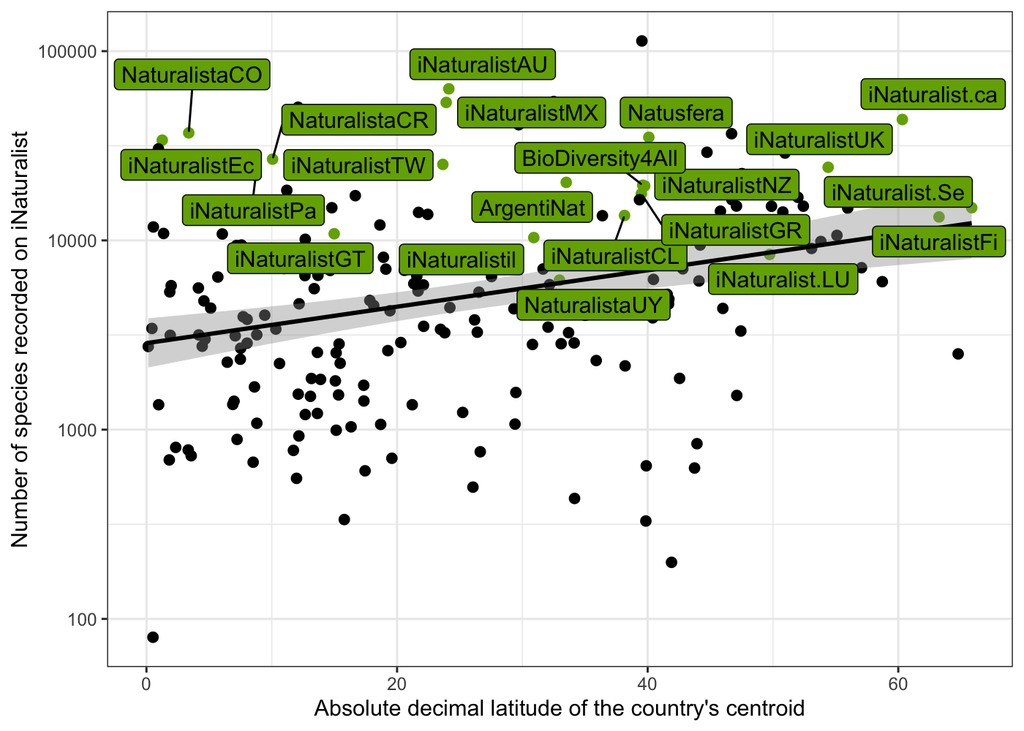

Number of species recorded on iNaturalist vs country’s centroid latitude

```r
## species
ggplot(data_variables %>% mutate(has_node = as.character(has_node)),
       aes(abs(latitude), n_species, label = node_name)) +
  geom_point(aes(col=has_node), size=2, show.legend = F) +
  scale_color_manual(values = c('black', '#74AC00')) +
  geom_smooth(method='lm', colour = 'black') +
  # geom_abline(lwd = 1.5, linetype = 'dashed', col = 'orange') +
  geom_label_repel(aes(fill=has_node),
                   colour = "black", #fontface = "bold",
                   segment.color = 'black',
                   show.legend = F, max.overlaps= Inf) +
  scale_fill_manual(values = c('#F7F7F7', '#74AC00')) +
  labs(x='Absolute decimal latitude of the country\'s centroid',
       y='Number of species recorded on iNaturalist') +
  #scale_x_log10() +
  scale_y_log10() +
  theme_bw()
```

### Number of species reported on IUCN

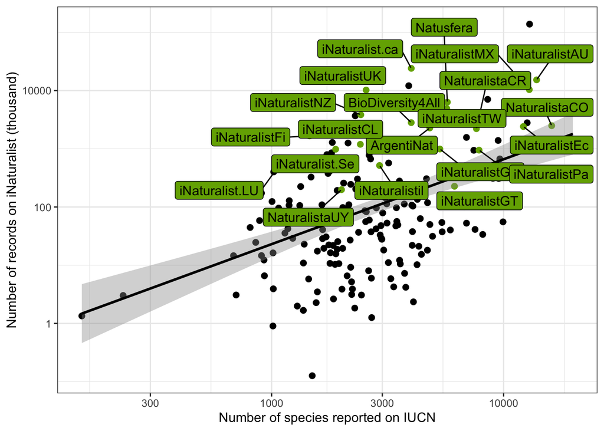

Number of records on iNaturalist vs number of species reported on IUCN

```r
## records
ggplot(data_variables %>% mutate(has_node = as.character(has_node)),
       aes(iucn_species, n_records/1000, label = node_name)) +
  geom_point(aes(col=has_node), size=2, show.legend = F) +
  scale_color_manual(values = c('black', '#74AC00')) +
  geom_smooth(method='lm', colour = 'black') +
  # geom_abline(lwd = 1.5, linetype = 'dashed', col = 'orange') +
  geom_label_repel(aes(fill=has_node),
                   colour = "black", #fontface = "bold",
                   segment.color = 'black',
                   show.legend = F, max.overlaps= Inf) +
  scale_fill_manual(values = c('#F7F7F7', '#74AC00')) +
  labs(x='Number of species reported on IUCN',
       y='Number of records on iNaturalist (thousand)') +
  scale_x_log10() + scale_y_log10() +
  theme_bw()
```

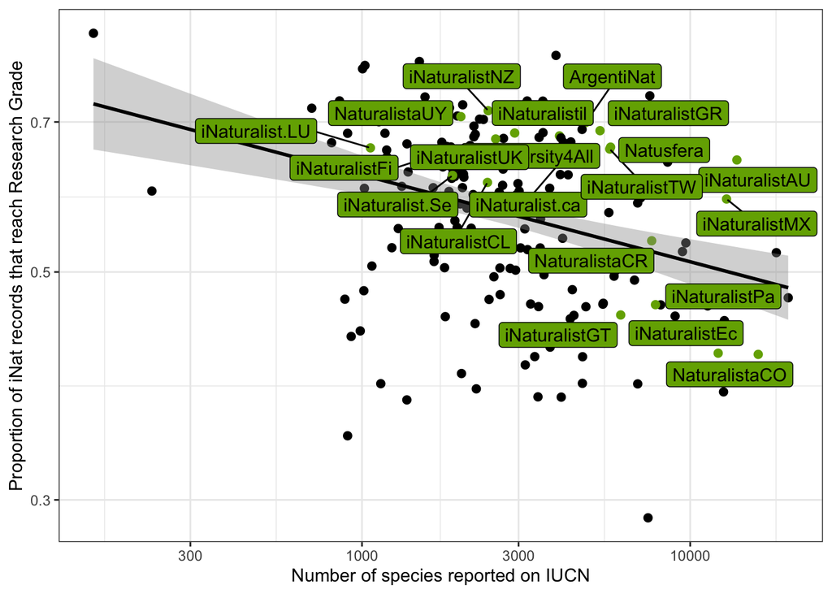

Proportion of Research Grade iNat records vs number of species reported on IUCN

```r
## records in research grade
ggplot(data_variables %>% mutate(has_node = as.character(has_node)),
       aes(iucn_species, p_research_grade, label = node_name)) +
  geom_point(aes(col=has_node), size=2, show.legend = F) +
  scale_color_manual(values = c('black', '#74AC00')) +
  geom_smooth(method='lm', colour = 'black') +
  # geom_abline(lwd = 1.5, linetype = 'dashed', col = 'orange') +
  geom_label_repel(aes(fill=has_node),
                   colour = "black", #fontface = "bold",
                   segment.color = 'black',
                   show.legend = F, max.overlaps= Inf) +
  scale_fill_manual(values = c('#F7F7F7', '#74AC00')) +
  labs(x='Number of species reported on IUCN',
       y='Proportion of iNat records that reach Research Grade') +
  scale_x_log10() + scale_y_log10() +
  theme_bw()
```

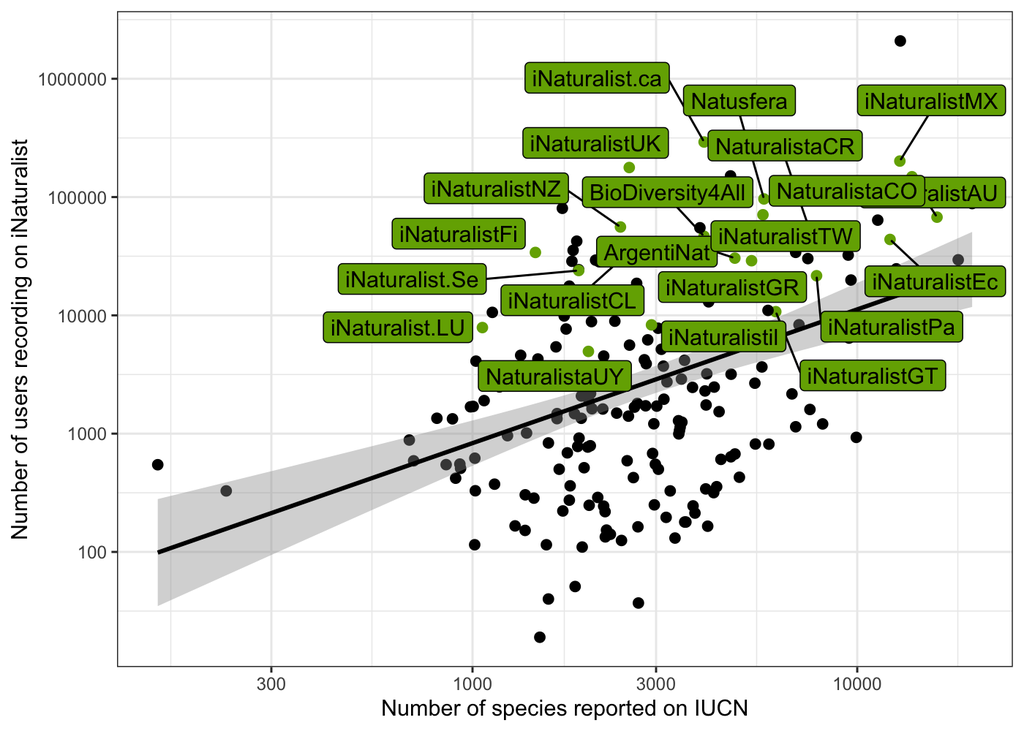

Number of users recording on iNaturalist vs number of species reported on IUCN

```r
## users
ggplot(data_variables %>% mutate(has_node = as.character(has_node)),
       aes(iucn_species,n_users, label = node_name)) +
  geom_point(aes(col=has_node), size=2, show.legend = F) +
  scale_color_manual(values = c('black', '#74AC00')) +
  geom_smooth(method='lm', colour = 'black') +
  # geom_abline(lwd = 1.5, linetype = 'dashed', col = 'orange') +
  geom_label_repel(aes(fill=has_node),
                   colour = "black", #fontface = "bold",
                   segment.color = 'black',
                   show.legend = F, max.overlaps= Inf) +
  scale_fill_manual(values = c('#F7F7F7', '#74AC00')) +
  labs(x='Number of species reported on IUCN',
       y='Number of users recording on iNaturalist') +
  scale_x_log10() + scale_y_log10() +
  theme_bw()
```

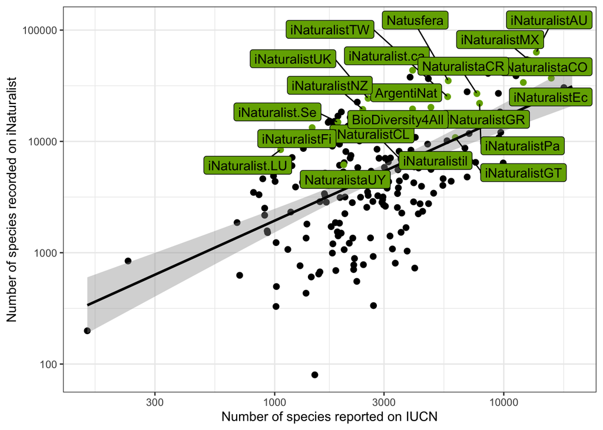

Number of species recorded on iNaturalist vs number of species reported on IUCN

```r
## species
ggplot(data_variables %>% mutate(has_node = as.character(has_node)),
       aes(iucn_species,n_species, label = node_name)) +
  geom_point(aes(col=has_node), size=2, show.legend = F) +
  scale_color_manual(values = c('black', '#74AC00')) +
  geom_smooth(method='lm', colour = 'black') +
  # geom_abline(lwd = 1.5, linetype = 'dashed', col = 'orange') +
  geom_label_repel(aes(fill=has_node),
                   colour = "black", #fontface = "bold",
                   segment.color = 'black',
                   show.legend = F, max.overlaps= Inf) +
  scale_fill_manual(values = c('#F7F7F7', '#74AC00')) +
  labs(x='Number of species reported on IUCN',
       y='Number of species recorded on iNaturalist') +
  scale_x_log10() + scale_y_log10() +
  theme_bw()
```

## Modelling

```r
data_regressions <- data_variables %>%
  select(-c(country_name, region, flag, node_name, node_id, node_type, node_year, place_id)) %>%
  drop_na(area, population, gdp_per_capita, gdp_in_research, latitude, iucn_species) %>%
  filter(country_code != 'US')


###

data_regressions %>%
  select(area, population, gdp_per_capita,
         gdp_in_research, latitude, iucn_species,
         has_node, neighbour_has_node) %>%
  cor() %>%
  kableExtra::kbl(digits=3,
                  format.args = list(big.mark = ',')) %>%
  kableExtra::kable_material('striped')
```

|  | area | population | gdp_per_capita | gdp_in_research | latitude | iucn_species | has_node | neighbour_has_node |
| --- | --- | --- | --- | --- | --- | --- | --- | --- |
| area | 1.000 | 0.369 | -0.030 | 0.057 | 0.020 | 0.329 | 0.135 | 0.090 |
| population | 0.369 | 1.000 | -0.104 | 0.064 | -0.004 | 0.390 | -0.057 | -0.051 |
| gdp_per_capita | -0.030 | -0.104 | 1.000 | 0.536 | 0.370 | -0.224 | 0.152 | 0.011 |
| gdp_in_research | 0.057 | 0.064 | 0.536 | 1.000 | 0.388 | -0.075 | 0.261 | 0.024 |
| latitude | 0.020 | -0.004 | 0.370 | 0.388 | 1.000 | -0.431 | -0.085 | -0.001 |
| iucn_species | 0.329 | 0.390 | -0.224 | -0.075 | -0.431 | 1.000 | 0.209 | 0.186 |
| has_node | 0.135 | -0.057 | 0.152 | 0.261 | -0.085 | 0.209 | 1.000 | 0.357 |
| neighbour_has_node | 0.090 | -0.051 | 0.011 | 0.024 | -0.001 | 0.186 | 0.357 | 1.000 |

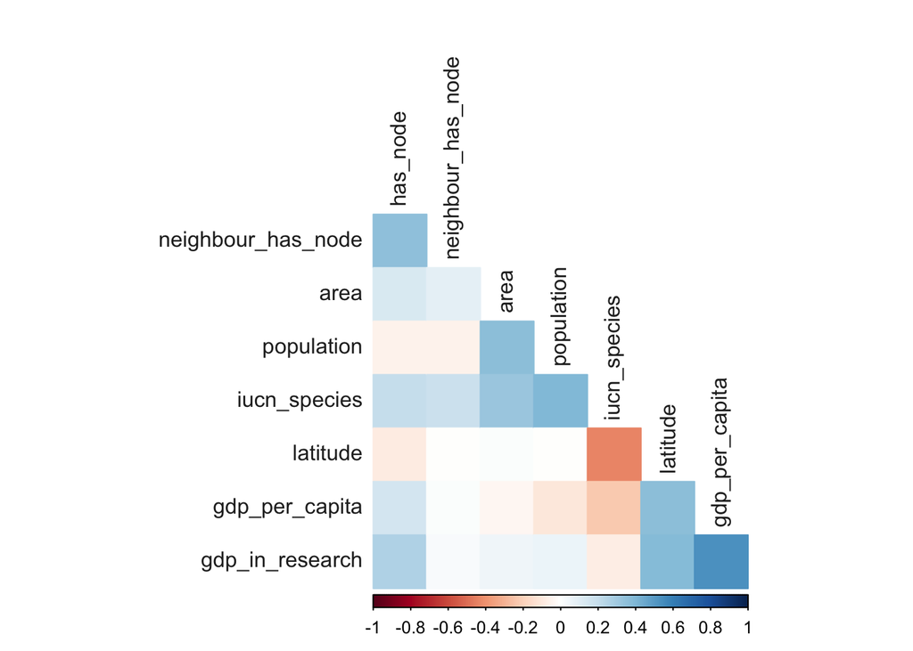

```r
data_regressions %>%
  select(area, population, gdp_per_capita,
         gdp_in_research, latitude, iucn_species,
         has_node, neighbour_has_node) %>%
  cor() %>%
  corrplot::corrplot(method = 'color',
                     diag = FALSE, type = 'lower',
                     order = 'AOE', tl.col = 'grey15')
```

```r
data_regressions %>%
  select(area, population, gdp_per_capita,
         gdp_in_research, latitude, iucn_species) %>%
  cor() %>%
  caret::findCorrelation(., cutoff=0.65, names=T)
```

```
character(0)
```

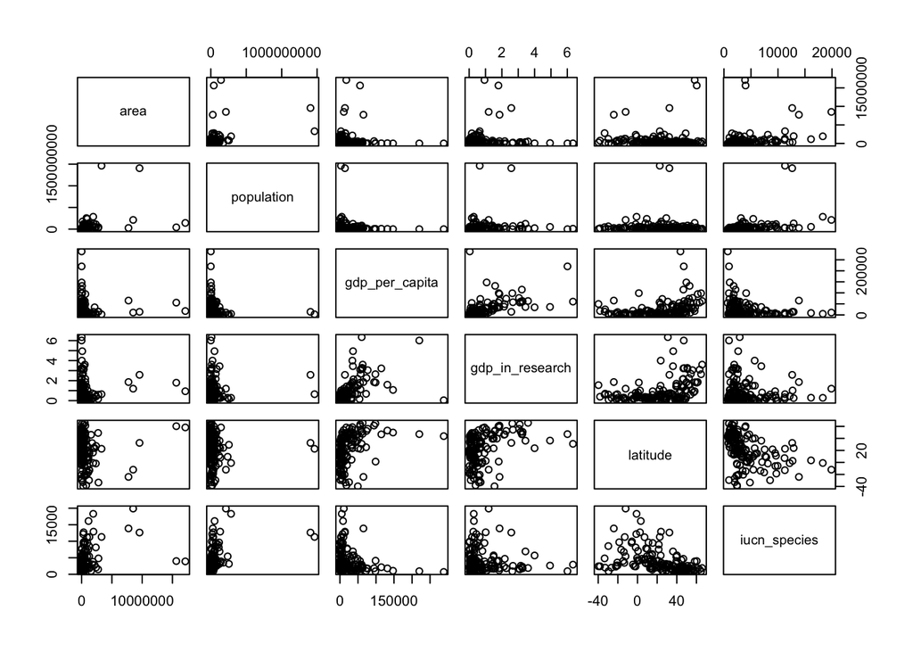

```r
data_regressions %>%
  select(area, population, gdp_per_capita,
         gdp_in_research, latitude, iucn_species) %>% pairs()
```

Number of countries analysed: 149.

### Historgrams: response variables

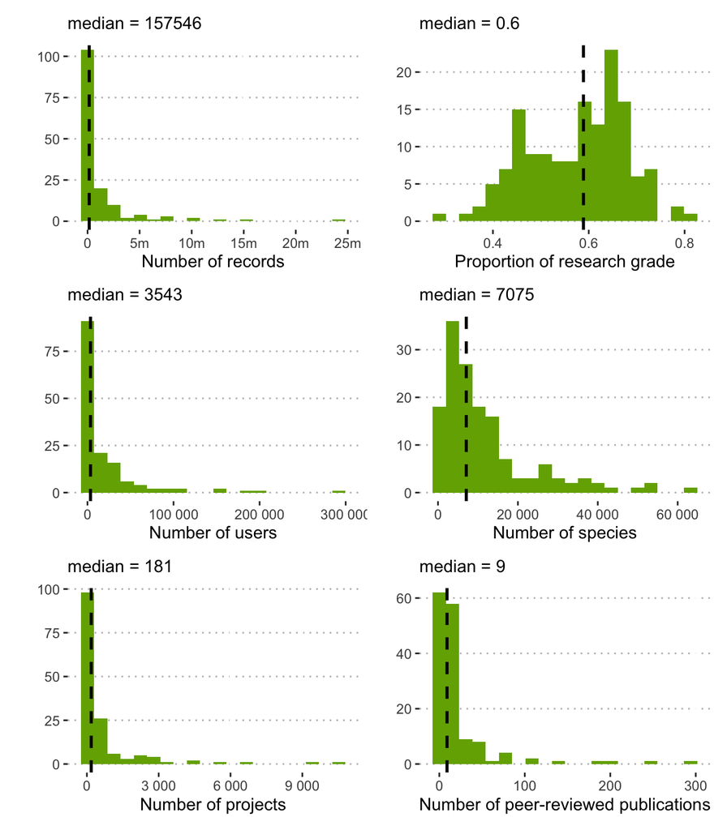

```r
plot_hist_n_records <- ggplot(data_regressions, aes(x = n_records)) +
  geom_histogram(fill = '#74ac00', bins = 20, show.legend = F) +
  scale_x_continuous(labels = scales::label_number(scale_cut = c(m = 1000000))) +
  geom_vline(xintercept = median(data_regressions$n_records, na.rm = T),
             color = "black", linetype = "dashed", lwd=1) +
  labs(x = 'Number of records', y = '',
       subtitle = str_glue('median = {round(median(data_regressions$n_records, na.rm = T),1)}')) +
  ggpubr::theme_pubclean()

plot_hist_p_research_grade <- ggplot(data_regressions, aes(x = p_research_grade)) +
  geom_histogram(fill = '#74ac00', bins = 20, show.legend = F) +
  scale_x_continuous(labels = scales::label_number(scale_cut = c(m = 1000000))) +
  geom_vline(xintercept = median(data_regressions$p_research_grade, na.rm = T),
             color = "black", linetype = "dashed", lwd=1) +
  labs(x = 'Proportion of research grade', y = '',
       subtitle = str_glue('median = {round(median(data_regressions$p_research_grade, na.rm = T),1)}')) +
  ggpubr::theme_pubclean()

plot_hist_n_users <- ggplot(data_regressions, aes(x = n_users)) +
  geom_histogram(fill = '#74ac00', bins = 20, show.legend = F) +
  scale_x_continuous(labels = scales::label_number(scale_cut = c(m = 1000000))) +
  geom_vline(xintercept = median(data_regressions$n_users),
             color = "black", linetype = "dashed", lwd=1) +
  labs(x = 'Number of users', y = '',
       subtitle = str_glue('median = {round(median(data_regressions$n_users, na.rm = T),1)}')) +
  ggpubr::theme_pubclean()

plot_hist_n_species <- ggplot(data_regressions, aes(x = n_species)) +
  geom_histogram(fill = '#74ac00', bins = 20, show.legend = F) +
  scale_x_continuous(labels = scales::label_number(scale_cut = c(m = 1000000))) +
  geom_vline(xintercept = median(data_regressions$n_species, na.rm = T),
             color = "black", linetype = "dashed", lwd=1) +
  labs(x = 'Number of species', y = '',
       subtitle = str_glue('median = {round(median(data_regressions$n_species, na.rm = T),1)}')) +
  ggpubr::theme_pubclean()

plot_hist_n_projects <- ggplot(data_regressions, aes(x = n_projects)) +
  geom_histogram(fill = '#74ac00', bins = 20, show.legend = F) +
  scale_x_continuous(labels = scales::label_number(scale_cut = c(m = 1000000))) +
  geom_vline(xintercept = median(data_regressions$n_projects, na.rm = T),
             color = "black", linetype = "dashed", lwd=1) +
  labs(x = 'Number of projects', y = '',
       subtitle = str_glue('median = {round(median(data_regressions$n_projects, na.rm = T),1)}')) +
  ggpubr::theme_pubclean()

plot_hist_n_literature <- ggplot(data_regressions, aes(x = n_literature)) +
  geom_histogram(fill = '#74ac00', bins = 20, show.legend = F) +
  scale_x_continuous(labels = scales::label_number(scale_cut = c(m = 1000000))) +
  geom_vline(xintercept = median(data_regressions$n_literature, na.rm = T),
             color = "black", linetype = "dashed", lwd=1) +
  labs(x = 'Number of peer-reviewed publications', y = '',
       subtitle = str_glue('median = {round(median(data_regressions$n_literature, na.rm = T),1)}')) +
  ggpubr::theme_pubclean()

(plot_hist_n_records + plot_hist_p_research_grade) / (plot_hist_n_users + plot_hist_n_species) /
(plot_hist_n_projects + plot_hist_n_literature)
```

```r
# save as 600x600
```

### Historgrams: explanatory variables

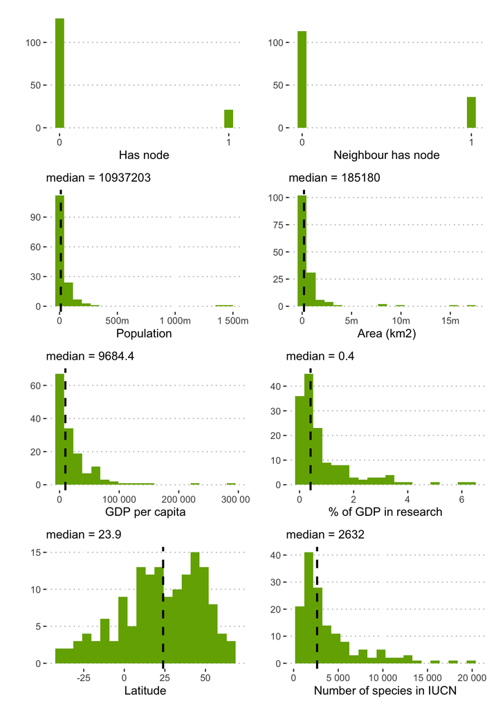

```r
plot_hist_has_node <- ggplot(data_regressions, aes(x = has_node)) +
  geom_histogram(fill = '#74ac00', bins = 20, show.legend = F) +
  scale_x_continuous(breaks = c(0,1)) +
  ylim(c(0,130)) +
  labs(x = 'Has node', y = '') +
  ggpubr::theme_pubclean()

plot_hist_neighbour_has_node <- ggplot(data_regressions, aes(x = neighbour_has_node)) +
  geom_histogram(fill = '#74ac00', bins = 20, show.legend = F) +
  scale_x_continuous(breaks = c(0,1)) +
  ylim(c(0,130)) +
  labs(x = 'Neighbour has node', y = '') +
  ggpubr::theme_pubclean()

plot_hist_population <- ggplot(data_regressions, aes(x = population)) +
  geom_histogram(fill = '#74ac00', bins = 20, show.legend = F) +
  scale_x_continuous(labels = scales::label_number(scale_cut = c(m = 1000000))) +
  geom_vline(xintercept = median(data_regressions$population),
             color = "black", linetype = "dashed", lwd=1) +
  labs(x = 'Population', y = '',
       subtitle = str_glue('median = {round(median(data_regressions$population, na.rm = T),1)}')) +
  ggpubr::theme_pubclean()

plot_hist_area <- ggplot(data_regressions, aes(x = area)) +
  geom_histogram(fill = '#74ac00', bins = 20, show.legend = F) +
  scale_x_continuous(labels = scales::label_number(scale_cut = c(m = 1000000))) +
  geom_vline(xintercept = median(data_regressions$area),
             color = "black", linetype = "dashed", lwd=1) +
  labs(x = 'Area (km2)', y = '',
       subtitle = str_glue('median = {round(median(data_regressions$area, na.rm = T),1)}')) +
  ggpubr::theme_pubclean()

plot_hist_gdp_per_capita <- ggplot(data_regressions, aes(x = gdp_per_capita)) +
  geom_histogram(fill = '#74ac00', bins = 20, show.legend = F) +
  scale_x_continuous(labels = scales::label_number(scale_cut = c(m = 1000000))) +
  geom_vline(xintercept = median(data_regressions$gdp_per_capita),
             color = "black", linetype = "dashed", lwd=1) +
  labs(x = 'GDP per capita', y = '',
       subtitle = str_glue('median = {round(median(data_regressions$gdp_per_capita, na.rm = T),1)}')) +
  ggpubr::theme_pubclean()

plot_hist_gdp_in_research <- ggplot(data_regressions, aes(x = gdp_in_research)) +
  geom_histogram(fill = '#74ac00', bins = 20, show.legend = F) +
  scale_x_continuous(labels = scales::label_number(scale_cut = c(m = 1000000))) +
  geom_vline(xintercept = median(data_regressions$gdp_in_research),
             color = "black", linetype = "dashed", lwd=1) +
  labs(x = '% of GDP in research', y = '',
       subtitle = str_glue('median = {round(median(data_regressions$gdp_in_research, na.rm = T),1)}')) +
  ggpubr::theme_pubclean()


plot_hist_latitude <- ggplot(data_regressions, aes(x = latitude)) +
  geom_histogram(fill = '#74ac00', bins = 20, show.legend = F) +
  scale_x_continuous(labels = scales::label_number(scale_cut = c(m = 1000000))) +
  geom_vline(xintercept = median(data_regressions$latitude),
             color = "black", linetype = "dashed", lwd=1) +
  labs(x = 'Latitude', y = '',
       subtitle = str_glue('median = {round(median(data_regressions$latitude, na.rm = T),1)}')) +
  ggpubr::theme_pubclean()

plot_hist_iucn_species <- ggplot(data_regressions, aes(x = iucn_species)) +
  geom_histogram(fill = '#74ac00', bins = 20, show.legend = F) +
  scale_x_continuous(labels = scales::label_number(scale_cut = c(m = 1000000))) +
  geom_vline(xintercept = median(data_regressions$iucn_species),
             color = "black", linetype = "dashed", lwd=1) +
  labs(x = 'Number of species in IUCN', y = '',
       subtitle = str_glue('median = {round(median(data_regressions$iucn_species, na.rm = T),1)}')) +
  ggpubr::theme_pubclean()

(plot_hist_has_node + plot_hist_neighbour_has_node) / (plot_hist_population + plot_hist_area) /
(plot_hist_gdp_per_capita + plot_hist_gdp_in_research) / (plot_hist_latitude + plot_hist_iucn_species)
```

```r
# save as 600x600
```

## Non-parametric test

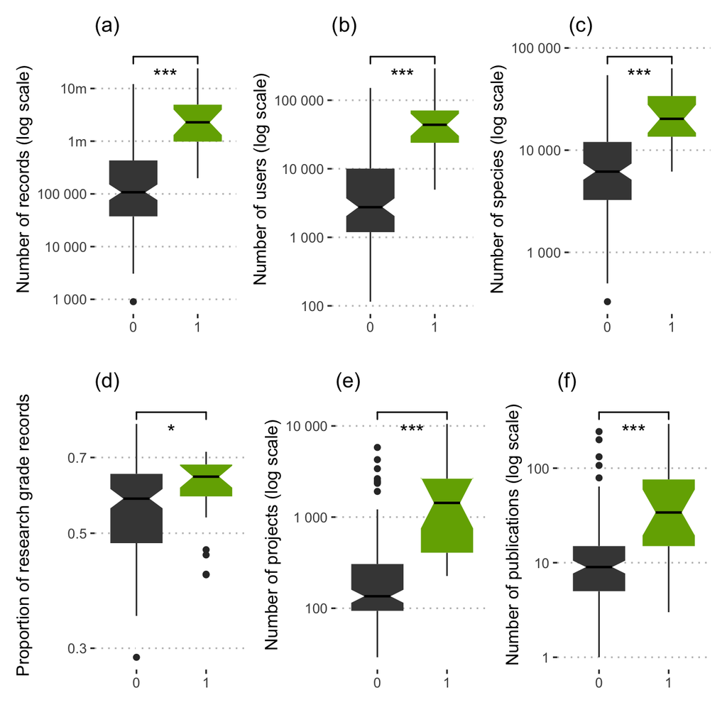

```r
plot_response_boxplots <- function(data_regressions, variable_name, plot=T) {

  labels <- c(n_records = "Number of records (log scale)",
              n_users = "Number of users (log scale)",
              n_species = "Number of species (log scale)",
              p_research_grade = "Proportion of research grade records",
              n_projects = "Number of projects (log scale)",
              n_literature = "Number of publications (log scale)")

  y_label <- labels[[variable_name]]

  letter_plot <- c(n_records = '(a)',
                   n_users = '(b)',
                   n_species = '(c)',
                   p_research_grade = '(d)',
                   n_projects  = '(e)',
                   n_literature = '(f)')

  ggplot(data_regressions %>%
           mutate(has_node = factor(has_node)),
         aes(x = has_node, y = !!sym(variable_name), fill=has_node)) +
    geom_boxplot(notch = T, linewidth = 0,
                 median.color = "black",
                 whisker.linewidth = 0.5,
                 median.linewidth = 0.8,
                 show.legend = F) +
    # geom_jitter(width = 0.1, alpha = 0.5, size = 1.5, show.legend = F) +
    scale_fill_manual(values = c('#454545', '#74AC00')) +
    scale_y_log10(labels = scales::label_number(scale_cut = c(m = 1000000))) +
    xlab("") +
    ylab(y_label) +
    ggsignif::geom_signif(comparisons = list(c("0", "1")),
                          map_signif_level = TRUE,
                          textsize = 5, vjust = 2) +
    ggpubr::theme_pubclean() +
    ggtitle(letter_plot[[variable_name]])
}

boxplot_n_records <- plot_response_boxplots(data_regressions, 'n_records')
boxplot_n_users <- plot_response_boxplots(data_regressions, 'n_users')
boxplot_n_species <- plot_response_boxplots(data_regressions, 'n_species')
boxplot_p_research <- plot_response_boxplots(data_regressions, 'p_research_grade')
boxplot_n_projects <- plot_response_boxplots(data_regressions, 'n_projects')
boxplot_n_literature <- plot_response_boxplots(data_regressions, 'n_literature')

(boxplot_n_records + boxplot_n_users + boxplot_n_species) /
(boxplot_p_research + boxplot_n_projects + boxplot_n_literature)
```

```r
# save 800 x 600
```

Are countries with a node generally higher/lower in records than those without?

```r
wilcox.test(n_records ~ has_node, data = data_regressions)
```

```
    Wilcoxon rank sum test with continuity correction

data:  n_records by has_node
W = 319, p-value = 0.00000002282
alternative hypothesis: true location shift is not equal to 0
```

```r
wilcox.test(n_users ~ has_node, data = data_regressions)
```

```
    Wilcoxon rank sum test with continuity correction

data:  n_users by has_node
W = 295, p-value = 0.00000001065
alternative hypothesis: true location shift is not equal to 0
```

```r
wilcox.test(n_species ~ has_node, data = data_regressions)
```

```
    Wilcoxon rank sum test with continuity correction

data:  n_species by has_node
W = 401.5, p-value = 0.0000002762
alternative hypothesis: true location shift is not equal to 0
```

```r
wilcox.test(p_research_grade ~ has_node, data = data_regressions)
```

```
    Wilcoxon rank sum test with continuity correction

data:  p_research_grade by has_node
W = 964, p-value = 0.03842
alternative hypothesis: true location shift is not equal to 0
```

```r
wilcox.test(n_projects ~ has_node, data = data_regressions)
```

```
    Wilcoxon rank sum test with continuity correction

data:  n_projects by has_node
W = 272, p-value = 0.000000005047
alternative hypothesis: true location shift is not equal to 0
```

```r
wilcox.test(n_literature ~ has_node, data = data_regressions)
```

```
    Wilcoxon rank sum test with continuity correction

data:  n_literature by has_node
W = 545, p-value = 0.00001298
alternative hypothesis: true location shift is not equal to 0
```

## GLM

### Standardise predictors and outcomes

These steps are the same as for the random forests

- Log transform (`log10`) and scale response (mean zero).
- Log transform (`log10`) and scale predictors (mean zero).
- Convert `latitude` to absolute latitude.
- Convert `has_node` and `neighbour_has_node` to factor.

```r
# variables that need to be log transformed
data_regressions %>%
  select(where(is.numeric) &
           where(~max(., na.rm = TRUE) > 1000)) %>%
    summary()
```

```
   n_records           n_users         n_species       n_projects
 Min.   :     901   Min.   :   115   Min.   :  329   Min.   :   29.0
 1st Qu.:   42356   1st Qu.:  1339   1st Qu.: 3515   1st Qu.:   97.0
 Median :  157546   Median :  3543   Median : 7075   Median :  181.0
 Mean   : 1256076   Mean   : 19873   Mean   :11781   Mean   :  706.5
 3rd Qu.:  983567   3rd Qu.: 21900   3rd Qu.:14884   3rd Qu.:  523.0
 Max.   :24138580   Max.   :292112   Max.   :63244   Max.   :10527.0
      area            population         gdp_per_capita      iucn_species
 Min.   :      75   Min.   :     38341   Min.   :   233.8   Min.   :  685
 1st Qu.:   41540   1st Qu.:   3935766   1st Qu.:  3173.3   1st Qu.: 1785
 Median :  185180   Median :  10937203   Median :  9684.4   Median : 2632
 Mean   :  817046   Mean   :  50624791   Mean   : 24707.4   Mean   : 3997
 3rd Qu.:  606410   3rd Qu.:  38430770   3rd Qu.: 32312.3   3rd Qu.: 4694
 Max.   :17125190   Max.   :1463865525   Max.   :288001.6   Max.   :19891
```

```r
data_glm <- data_regressions %>%
  mutate(n_records = scale(log10(n_records))[,1]) %>%
  mutate(n_users = scale(log10(n_users))[,1]) %>%
  mutate(n_species = scale(log10(n_species))[,1]) %>%
  mutate(n_projects = scale(log10(n_projects))[,1]) %>%
  mutate(n_literature = scale(n_literature)[,1])

data_glm <- data_glm %>%
  mutate(area = scale(log10(area))[,1],
         population = scale(log10(population))[,1],
         gdp_per_capita = scale(log10(gdp_per_capita))[,1],
         latitude = scale(abs(latitude))[,1],
         iucn_species = scale(log10(iucn_species))[,1],
         has_node = as.factor(has_node),
         neighbour_has_node = as.factor(neighbour_has_node))

data_glm$has_node <- relevel(factor(data_glm$has_node), ref = "0")
data_glm$neighbour_has_node <- relevel(factor(data_glm$neighbour_has_node), ref = "0")
```

### Linear models

```r
lm_n_records <- lm(n_records ~
                        area + population +
                        gdp_per_capita + gdp_in_research +
                        latitude + iucn_species +
                        has_node + neighbour_has_node,
                      data = data_glm)

lm_n_users <- lm(n_users ~
                        area + population +
                        gdp_per_capita + gdp_in_research +
                        latitude + iucn_species +
                        has_node + neighbour_has_node,
                      data = data_glm)

lm_n_species <- lm(n_species ~
                        area + population +
                        gdp_per_capita + gdp_in_research +
                        latitude + iucn_species +
                        has_node + neighbour_has_node,
                      data = data_glm)

lm_n_projects <- lm(n_projects ~
                        area + population +
                        gdp_per_capita + gdp_in_research +
                        latitude + iucn_species +
                        has_node + neighbour_has_node,
                      data = data_glm)

lm_p_research_grade <- lm(p_research_grade ~
                        area + population +
                        gdp_per_capita + gdp_in_research +
                        latitude + iucn_species +
                        has_node + neighbour_has_node,
                      data = data_glm)

lm_n_literature <- lm(n_literature ~
                        area + population +
                        gdp_per_capita + gdp_in_research +
                        latitude + iucn_species +
                        has_node + neighbour_has_node,
                      data = data_glm)
```

### Model performance

```r
print('Number of records');performance::performance(lm_n_records)
```

```
[1] "Number of records"
```

```
# Indices of model performance

AIC   |  AICc |   BIC |    R2 | R2 (adj.) |  RMSE | Sigma
---------------------------------------------------------
233.7 | 235.3 | 263.7 | 0.753 |     0.739 | 0.496 | 0.511
```

```r
print('Number of users');performance::performance(lm_n_users)
```

```
[1] "Number of users"
```

```
# Indices of model performance

AIC   |  AICc |   BIC |    R2 | R2 (adj.) |  RMSE | Sigma
---------------------------------------------------------
197.0 | 198.6 | 227.0 | 0.807 |     0.796 | 0.438 | 0.452
```

```r
print('Number of species');performance::performance(lm_n_species)
```

```
[1] "Number of species"
```

```
# Indices of model performance

AIC   |  AICc |   BIC |    R2 | R2 (adj.) |  RMSE | Sigma
---------------------------------------------------------
218.2 | 219.8 | 248.2 | 0.777 |     0.764 | 0.471 | 0.485
```

```r
print('Number of projects');performance::performance(lm_n_projects)
```

```
[1] "Number of projects"
```

```
# Indices of model performance

AIC   |  AICc |   BIC |    R2 | R2 (adj.) |  RMSE | Sigma
---------------------------------------------------------
252.4 | 254.0 | 282.5 | 0.720 |     0.704 | 0.528 | 0.545
```

```r
print('Proportion of research-grade');performance::performance(lm_p_research_grade)
```

```
[1] "Proportion of research-grade"
```

```
# Indices of model performance

AIC    |   AICc |    BIC |    R2 | R2 (adj.) |  RMSE | Sigma
------------------------------------------------------------
-284.1 | -282.5 | -254.1 | 0.297 |     0.257 | 0.087 | 0.090
```

```r
print('Number of derived publications');performance::performance(lm_n_literature)
```

```
[1] "Number of derived publications"
```

```
# Indices of model performance

AIC   |  AICc |   BIC |    R2 | R2 (adj.) |  RMSE | Sigma
---------------------------------------------------------
352.9 | 354.5 | 382.9 | 0.450 |     0.418 | 0.739 | 0.763
```

```r
tab_model(lm_n_records, lm_n_users, lm_n_species, lm_n_projects, lm_p_research_grade, lm_n_literature)
```

|  | n records |  |  | n users |  |  | n species |  |  | n projects |  |  | p research grade |  |  | n literature |  |  |
| --- | --- | --- | --- | --- | --- | --- | --- | --- | --- | --- | --- | --- | --- | --- | --- | --- | --- | --- |
| Predictors | Estimates | CI | p | Estimates | CI | p | Estimates | CI | p | Estimates | CI | p | Estimates | CI | p | Estimates | CI | p |
| (Intercept) | -0.06 | -0.19 – 0.08 | 0.415 | -0.07 | -0.19 – 0.05 | 0.255 | -0.03 | -0.16 – 0.10 | 0.685 | -0.11 | -0.26 – 0.03 | 0.124 | 0.57 | 0.55 – 0.60 | **<0.001** | 0.05 | -0.15 – 0.26 | 0.616 |
| area | -0.11 | -0.27 – 0.05 | 0.167 | -0.20 | -0.34 – -0.05 | **0.007** | -0.16 | -0.31 – -0.00 | **0.043** | -0.01 | -0.18 – 0.16 | 0.926 | -0.00 | -0.03 – 0.03 | 0.869 | 0.06 | -0.18 – 0.30 | 0.623 |
| population | 0.31 | 0.15 – 0.47 | **<0.001** | 0.32 | 0.18 – 0.46 | **<0.001** | 0.22 | 0.07 – 0.37 | **0.005** | 0.32 | 0.15 – 0.50 | **<0.001** | -0.00 | -0.03 – 0.03 | 0.988 | 0.23 | -0.01 – 0.47 | 0.058 |
| gdp per capita | 0.33 | 0.17 – 0.48 | **<0.001** | 0.39 | 0.25 – 0.52 | **<0.001** | 0.17 | 0.03 – 0.31 | **0.021** | 0.30 | 0.14 – 0.46 | **<0.001** | 0.02 | -0.01 – 0.05 | 0.151 | 0.20 | -0.03 – 0.42 | 0.082 |
| gdp in research | -0.01 | -0.11 – 0.09 | 0.799 | -0.02 | -0.11 – 0.07 | 0.642 | -0.03 | -0.13 – 0.06 | 0.505 | -0.03 | -0.14 – 0.08 | 0.570 | 0.00 | -0.01 – 0.02 | 0.624 | -0.13 | -0.28 – 0.02 | 0.090 |
| latitude | 0.53 | 0.36 – 0.70 | **<0.001** | 0.54 | 0.38 – 0.69 | **<0.001** | 0.67 | 0.50 – 0.83 | **<0.001** | 0.30 | 0.12 – 0.49 | **0.001** | 0.03 | 0.00 – 0.06 | **0.028** | 0.32 | 0.07 – 0.58 | **0.014** |
| iucn species | 0.68 | 0.51 – 0.85 | **<0.001** | 0.71 | 0.57 – 0.86 | **<0.001** | 0.93 | 0.77 – 1.09 | **<0.001** | 0.53 | 0.35 – 0.71 | **<0.001** | -0.01 | -0.04 – 0.02 | 0.665 | 0.52 | 0.27 – 0.77 | **<0.001** |
| has node [1] | 0.45 | 0.17 – 0.73 | **0.002** | 0.44 | 0.19 – 0.69 | **0.001** | 0.22 | -0.04 – 0.49 | 0.101 | 0.78 | 0.48 – 1.08 | **<0.001** | 0.02 | -0.03 – 0.07 | 0.332 | 0.38 | -0.04 – 0.80 | 0.076 |
| neighbour has node [1] | 0.02 | -0.20 – 0.23 | 0.869 | 0.11 | -0.08 – 0.30 | 0.257 | 0.10 | -0.10 – 0.30 | 0.337 | 0.13 | -0.10 – 0.36 | 0.266 | -0.02 | -0.05 – 0.02 | 0.412 | 0.04 | -0.28 – 0.36 | 0.802 |
| Observations | 149 |  |  | 149 |  |  | 149 |  |  | 149 |  |  | 149 |  |  | 149 |  |  |
| R<sup>2</sup> / R<sup>2</sup> adjusted | 0.753 / 0.739 |  |  | 0.807 / 0.796 |  |  | 0.777 / 0.764 |  |  | 0.720 / 0.704 |  |  | 0.297 / 0.257 |  |  | 0.450 / 0.418 |  |  |

### Model estimates

```r
tidy_models <- bind_rows(
  tidy(lm_n_records, conf.int = TRUE) %>%
    mutate(model = "Number of records"),
  tidy(lm_n_users, conf.int = TRUE) %>%
    mutate(model = "Number of users"),
  tidy(lm_n_species, conf.int = TRUE) %>%
    mutate(model = "Number of species"),
  tidy(lm_n_projects, conf.int = TRUE) %>%
    mutate(model = "Number of projects"),
  tidy(lm_p_research_grade,  conf.int = TRUE) %>%
    mutate(model = "Proportion of research grade"),
  tidy(lm_n_literature, conf.int = TRUE) %>%
    mutate(model = "Number of publications")) %>%
  # drop intercept rows
  filter(term != "(Intercept)") %>%
  # add significance markers
  mutate(
    sig_stars = case_when(
      p.value < 0.001 ~ "***",
      p.value < 0.01  ~ "**",
      p.value < 0.05  ~ "*",
      TRUE            ~ ""),
    is_sig = p.value < 0.05,
    # relevel variables
    model = fct_relevel(
      model,
      "Number of records",
      "Number of users",
      "Number of species",
      "Number of projects",
      "Proportion of research grade",
      "Number of publications"),
    term = fct_relevel(
      term,
      "neighbour_has_node1",
      "has_node1",
      "latitude",
      "iucn_species",
      "gdp_in_research",
      "gdp_per_capita",
      "population",
      "area"))

tidy_models %>%
  relocate(model) %>% knitr::kable(digits = 3)
```

| model | term | estimate | std.error | statistic | p.value | conf.low | conf.high | sig_stars | is_sig |
| --- | --- | --- | --- | --- | --- | --- | --- | --- | --- |
| Number of records | area | -0.113 | 0.082 | -1.390 | 0.167 | -0.274 | 0.048 |  | FALSE |
| Number of records | population | 0.308 | 0.081 | 3.787 | 0.000 | 0.147 | 0.469 | *** | TRUE |
| Number of records | gdp_per_capita | 0.325 | 0.076 | 4.270 | 0.000 | 0.175 | 0.476 | *** | TRUE |
| Number of records | gdp_in_research | -0.013 | 0.051 | -0.256 | 0.799 | -0.114 | 0.088 |  | FALSE |
| Number of records | latitude | 0.531 | 0.087 | 6.095 | 0.000 | 0.359 | 0.703 | *** | TRUE |
| Number of records | iucn_species | 0.681 | 0.085 | 8.039 | 0.000 | 0.514 | 0.849 | *** | TRUE |
| Number of records | has_node1 | 0.452 | 0.142 | 3.190 | 0.002 | 0.172 | 0.733 | ** | TRUE |
| Number of records | neighbour_has_node1 | 0.018 | 0.109 | 0.165 | 0.869 | -0.197 | 0.233 |  | FALSE |
| Number of users | area | -0.196 | 0.072 | -2.723 | 0.007 | -0.339 | -0.054 | ** | TRUE |
| Number of users | population | 0.322 | 0.072 | 4.472 | 0.000 | 0.179 | 0.464 | *** | TRUE |
| Number of users | gdp_per_capita | 0.386 | 0.067 | 5.721 | 0.000 | 0.252 | 0.519 | *** | TRUE |
| Number of users | gdp_in_research | -0.021 | 0.045 | -0.466 | 0.642 | -0.111 | 0.068 |  | FALSE |
| Number of users | latitude | 0.536 | 0.077 | 6.957 | 0.000 | 0.384 | 0.688 | *** | TRUE |
| Number of users | iucn_species | 0.713 | 0.075 | 9.516 | 0.000 | 0.565 | 0.861 | *** | TRUE |
| Number of users | has_node1 | 0.440 | 0.125 | 3.506 | 0.001 | 0.192 | 0.688 | *** | TRUE |
| Number of users | neighbour_has_node1 | 0.109 | 0.096 | 1.138 | 0.257 | -0.081 | 0.299 |  | FALSE |
| Number of species | area | -0.158 | 0.077 | -2.038 | 0.043 | -0.311 | -0.005 | * | TRUE |
| Number of species | population | 0.221 | 0.077 | 2.855 | 0.005 | 0.068 | 0.373 | ** | TRUE |
| Number of species | gdp_per_capita | 0.169 | 0.072 | 2.342 | 0.021 | 0.026 | 0.313 | * | TRUE |
| Number of species | gdp_in_research | -0.032 | 0.049 | -0.668 | 0.505 | -0.129 | 0.064 |  | FALSE |
| Number of species | latitude | 0.668 | 0.083 | 8.079 | 0.000 | 0.505 | 0.832 | *** | TRUE |
| Number of species | iucn_species | 0.931 | 0.080 | 11.574 | 0.000 | 0.772 | 1.091 | *** | TRUE |
| Number of species | has_node1 | 0.222 | 0.135 | 1.649 | 0.101 | -0.044 | 0.488 |  | FALSE |
| Number of species | neighbour_has_node1 | 0.099 | 0.103 | 0.963 | 0.337 | -0.105 | 0.303 |  | FALSE |
| Number of projects | area | -0.008 | 0.087 | -0.094 | 0.926 | -0.180 | 0.163 |  | FALSE |
| Number of projects | population | 0.325 | 0.087 | 3.746 | 0.000 | 0.153 | 0.496 | *** | TRUE |
| Number of projects | gdp_per_capita | 0.297 | 0.081 | 3.662 | 0.000 | 0.137 | 0.458 | *** | TRUE |
| Number of projects | gdp_in_research | -0.031 | 0.055 | -0.569 | 0.570 | -0.139 | 0.077 |  | FALSE |
| Number of projects | latitude | 0.303 | 0.093 | 3.269 | 0.001 | 0.120 | 0.487 | ** | TRUE |
| Number of projects | iucn_species | 0.529 | 0.090 | 5.858 | 0.000 | 0.350 | 0.707 | *** | TRUE |
| Number of projects | has_node1 | 0.780 | 0.151 | 5.166 | 0.000 | 0.482 | 1.079 | *** | TRUE |
| Number of projects | neighbour_has_node1 | 0.129 | 0.116 | 1.116 | 0.266 | -0.100 | 0.358 |  | FALSE |
| Proportion of research grade | area | -0.002 | 0.014 | -0.165 | 0.869 | -0.031 | 0.026 |  | FALSE |
| Proportion of research grade | population | 0.000 | 0.014 | -0.016 | 0.988 | -0.029 | 0.028 |  | FALSE |
| Proportion of research grade | gdp_per_capita | 0.019 | 0.013 | 1.443 | 0.151 | -0.007 | 0.046 |  | FALSE |
| Proportion of research grade | gdp_in_research | 0.004 | 0.009 | 0.492 | 0.624 | -0.013 | 0.022 |  | FALSE |
| Proportion of research grade | latitude | 0.034 | 0.015 | 2.226 | 0.028 | 0.004 | 0.064 | * | TRUE |
| Proportion of research grade | iucn_species | -0.006 | 0.015 | -0.434 | 0.665 | -0.036 | 0.023 |  | FALSE |
| Proportion of research grade | has_node1 | 0.024 | 0.025 | 0.974 | 0.332 | -0.025 | 0.074 |  | FALSE |
| Proportion of research grade | neighbour_has_node1 | -0.016 | 0.019 | -0.823 | 0.412 | -0.054 | 0.022 |  | FALSE |
| Number of publications | area | 0.060 | 0.122 | 0.492 | 0.623 | -0.181 | 0.300 |  | FALSE |
| Number of publications | population | 0.232 | 0.121 | 1.915 | 0.058 | -0.008 | 0.472 |  | FALSE |
| Number of publications | gdp_per_capita | 0.199 | 0.114 | 1.753 | 0.082 | -0.025 | 0.424 |  | FALSE |
| Number of publications | gdp_in_research | -0.131 | 0.076 | -1.707 | 0.090 | -0.282 | 0.021 |  | FALSE |
| Number of publications | latitude | 0.324 | 0.130 | 2.496 | 0.014 | 0.067 | 0.581 | * | TRUE |
| Number of publications | iucn_species | 0.516 | 0.126 | 4.079 | 0.000 | 0.266 | 0.766 | *** | TRUE |
| Number of publications | has_node1 | 0.378 | 0.212 | 1.787 | 0.076 | -0.040 | 0.796 |  | FALSE |
| Number of publications | neighbour_has_node1 | 0.041 | 0.162 | 0.251 | 0.802 | -0.280 | 0.361 |  | FALSE |

```r
tidy_models %>% filter(term=='has_node1')  %>% knitr::kable(digits = 3)
```

| term | estimate | std.error | statistic | p.value | conf.low | conf.high | model | sig_stars | is_sig |
| --- | --- | --- | --- | --- | --- | --- | --- | --- | --- |
| has_node1 | 0.452 | 0.142 | 3.190 | 0.002 | 0.172 | 0.733 | Number of records | ** | TRUE |
| has_node1 | 0.440 | 0.125 | 3.506 | 0.001 | 0.192 | 0.688 | Number of users | *** | TRUE |
| has_node1 | 0.222 | 0.135 | 1.649 | 0.101 | -0.044 | 0.488 | Number of species |  | FALSE |
| has_node1 | 0.780 | 0.151 | 5.166 | 0.000 | 0.482 | 1.079 | Number of projects | *** | TRUE |
| has_node1 | 0.024 | 0.025 | 0.974 | 0.332 | -0.025 | 0.074 | Proportion of research grade |  | FALSE |
| has_node1 | 0.378 | 0.212 | 1.787 | 0.076 | -0.040 | 0.796 | Number of publications |  | FALSE |